# Biostats exam I (test)

Filipe Alberto

2025-10-31

## Responses, individual points, and totals

|  | student | Percent | Points | Q.1 | Q.2 | Q.3 | Q.4 | Q.5 | Q.6 | Q.7 | Q.8 | Q.9 | Q.10 | Q.11 | Q.12 | Q.13 | Q.14 | Q.15 | Q.16 | Q.17 | Q.18 | Q.19 | Q.20 | Q.21 | Q.22 | Q.23 | Q.24 | Q.25 | Q.26 | … |
| --- | --- | --- | --- | --- | --- | --- | --- | --- | --- | --- | --- | --- | --- | --- | --- | --- | --- | --- | --- | --- | --- | --- | --- | --- | --- | --- | --- | --- | --- | --- |
| 1 | Nubi_Barbosa | 20 | 6 | 0 | 0 | 0 | 0 | 0 | 0 | 0 | 0 | 0 | 1 | 0 | 0 | 0 | 0 | 0 | 1 | 0 | 0 | 0 | 0 | 1 | 0 | 1 | 1 | 0 | 0 | … |
| 2 | Filipe_Alberto | 13.3 | 4 | 0 | 0 | 0 | 0 | 0 | 0 | 0 | 0 | 0 | 0 | 0 | 0 | 0 | 0 | 1 | 1 | 0 | 0 | 1 | 0 | 0 | 0 | 0 | 1 | 0 | 0 | … |
| 3 | Mike_Jackson | 16.7 | 5 | 1 | 0 | 0 | 0 | 0 | 1 | 0 | 0 | 1 | 0 | 0 | 0 | 0 | 0 | 0 | 0 | 0 | 0 | 1 | 0 | 0 | 0 | 0 | 0 | 0 | 0 | … |
| 4 | Flavia_Barbosa | 100 | 30 | 1 | 1 | 1 | 1 | 1 | 1 | 1 | 1 | 1 | 1 | 1 | 1 | 1 | 1 | 1 | 1 | 1 | 1 | 1 | 1 | 1 | 1 | 1 | 1 | 1 | 1 | … |
| 5 | John_Fond | 70 | 21 | 1 | 1 | 1 | 1 | 1 | 0 | 0 | 0 | 1 | 0 | 1 | 1 | 1 | 0 | 1 | 1 | 0 | 1 | 1 | 1 | 1 | 1 | 1 | 1 | 1 | 1 | … |
| 6 | Anne_Mary | 73.3 | 22 | 1 | 1 | 0 | 1 | 1 | 1 | 1 | 0 | 0 | 0 | 1 | 1 | 1 | 1 | 1 | 0 | 1 | 1 | 1 | 0 | 1 | 1 | 1 | 1 | 0 | 0 | … |
| 7 | Jacky_Chen | 70 | 21 | 1 | 1 | 1 | 1 | 1 | 1 | 0 | 0 | 0 | 0 | 1 | 0 | 1 | 1 | 1 | 1 | 1 | 1 | 1 | 1 | 0 | 0 | 0 | 0 | 1 | 1 | … |
| 8 | Mr_Bean | 46.7 | 14 | 1 | 1 | 0 | 1 | 1 | 0 | 1 | 0 | 0 | 0 | 1 | 1 | 1 | 1 | 0 | 0 | 0 | 0 | 0 | 1 | 1 | 0 | 0 | 0 | 1 | 0 | … |
| 9 | Super_Woman | 46.7 | 14 | 1 | 1 | 0 | 1 | 1 | 0 | 0 | 0 | 0 | 0 | 1 | 1 | 1 | 0 | 0 | 1 | 1 | 0 | 0 | 1 | 1 | 0 | 0 | 0 | 1 | 0 | … |
| 10 | Rocky_III | 73.3 | 22 | 1 | 1 | 0 | 1 | 1 | 0 | 1 | 1 | 1 | 0 | 1 | 1 | 1 | 0 | 0 | 1 | 1 | 0 | 0 | 1 | 1 | 1 | 1 | 1 | 1 | 0 | … |

[output cut: 2 more lines]

## Class frequency distribution

| Grade | Percent.limits | Frequency | Percent |
| --- | --- | --- | --- |
| A | 89.99-100.00 | 1 | 0.08 |
| B | 79.99-89.99 | 0 | 0.00 |
| C | 69.99-79.99 | 5 | 0.42 |
| D | 59.99-69.99 | 0 | 0.00 |
| E | 0.00-59.99 | 6 | 0.50 |

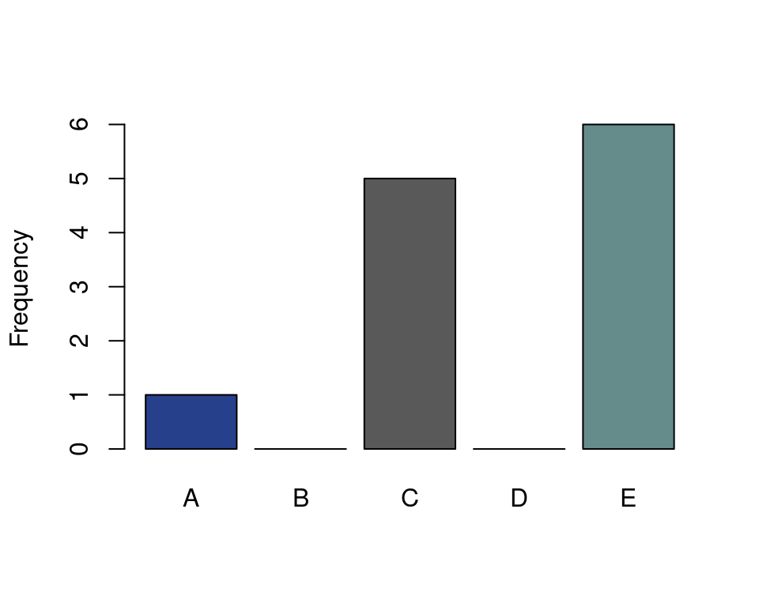

## Single question stats

### Exam: 25102300001

**Statistics for exam 25102300001; responses to Q.1**

| Response | Frequency | Percent | Biserial |
| --- | --- | --- | --- |
| A | 0 | 0.00 | NA |
| B | 2 | 33.33 | -0.94 |
| C | 0 | 0.00 | NA |
| #D# | 4 | 66.67 | 0.94 |
| E | 0 | 0.00 | NA |
| Total | 6 | 100.00 | NA |

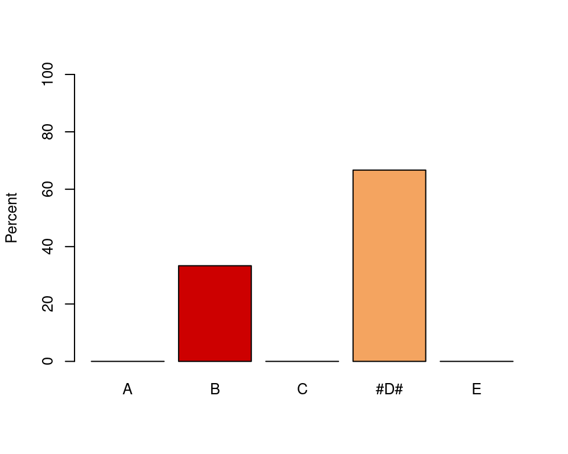

**Statistics for exam 25102300001; responses to Q.2**

| Response | Frequency | Percent | Biserial |
| --- | --- | --- | --- |
| A | 0 | 0.00 | NA |
| B | 1 | 16.67 | -0.52 |
| #C# | 4 | 66.67 | 0.94 |
| D | 1 | 16.67 | -0.67 |
| E | 0 | 0.00 | NA |
| Total | 6 | 100.01 | NA |

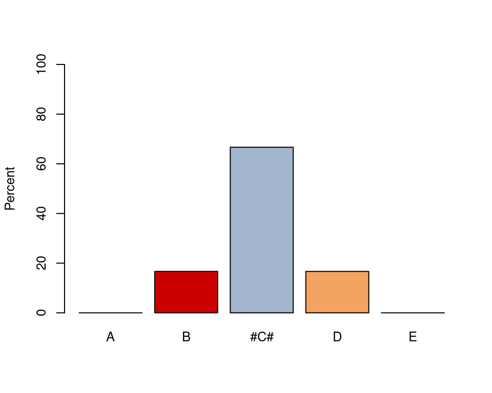

**Statistics for exam 25102300001; responses to Q.3**

| Response | Frequency | Percent | Biserial |
| --- | --- | --- | --- |
| A | 1 | 16.67 | -0.67 |
| B | 1 | 16.67 | 0.22 |
| #C# | 3 | 50.00 | 0.72 |
| D | 1 | 16.67 | -0.52 |
| E | 0 | 0.00 | NA |
| Total | 6 | 100.01 | NA |

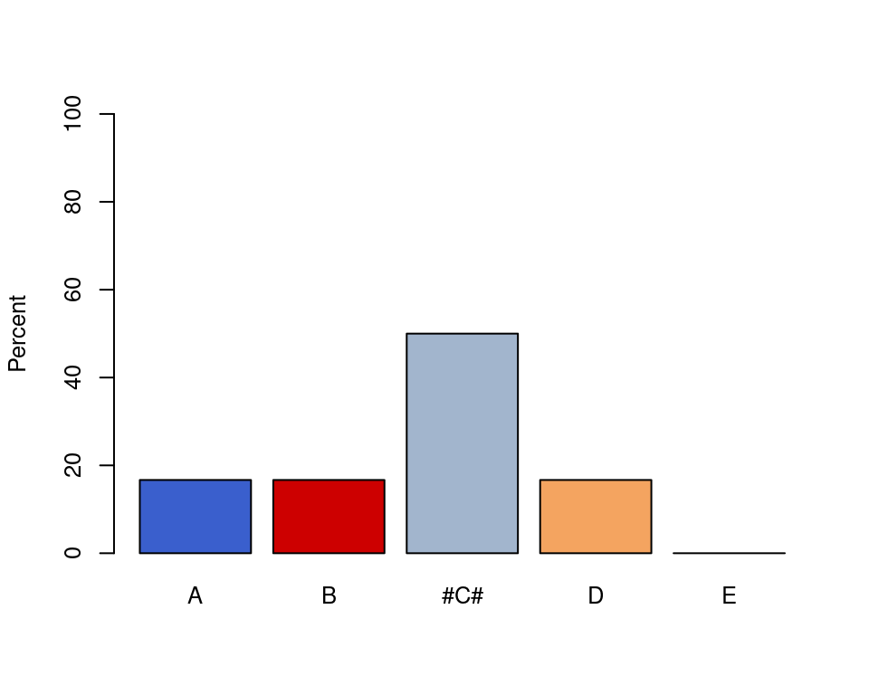

**Statistics for exam 25102300001; responses to Q.4**

| Response | Frequency | Percent | Biserial |
| --- | --- | --- | --- |
| #A# | 4 | 57.14 | 0.94 |
| B | 1 | 14.29 | -0.67 |
| C | 1 | 14.29 | -0.52 |
| D | 0 | 0.00 | NA |
| E | 1 | 14.29 | -0.52 |
| Total | 7 | 100.01 | NA |

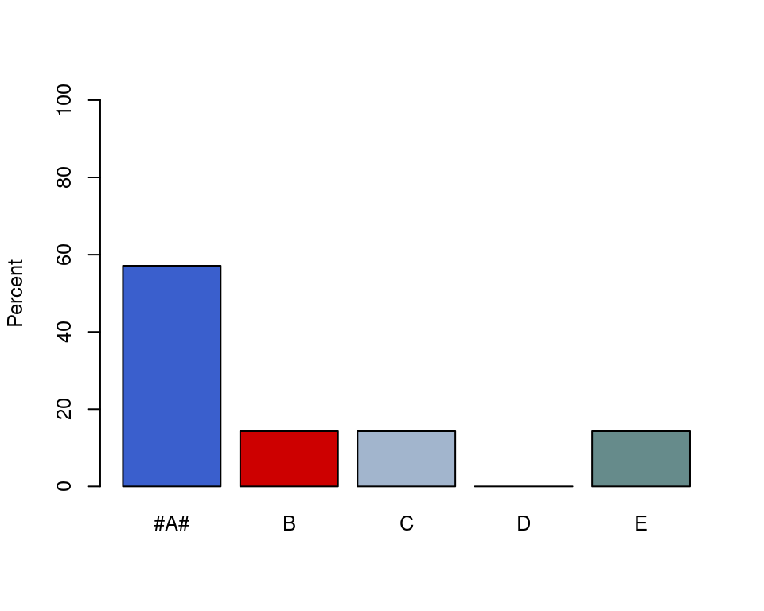

**Statistics for exam 25102300001; responses to Q.5**

| Response | Frequency | Percent | Biserial |
| --- | --- | --- | --- |
| A | 0 | 0.00 | NA |
| B | 1 | 16.67 | -0.52 |
| C | 1 | 16.67 | -0.67 |
| D | 0 | 0.00 | NA |
| #E# | 4 | 66.67 | 0.94 |
| Total | 6 | 100.01 | NA |

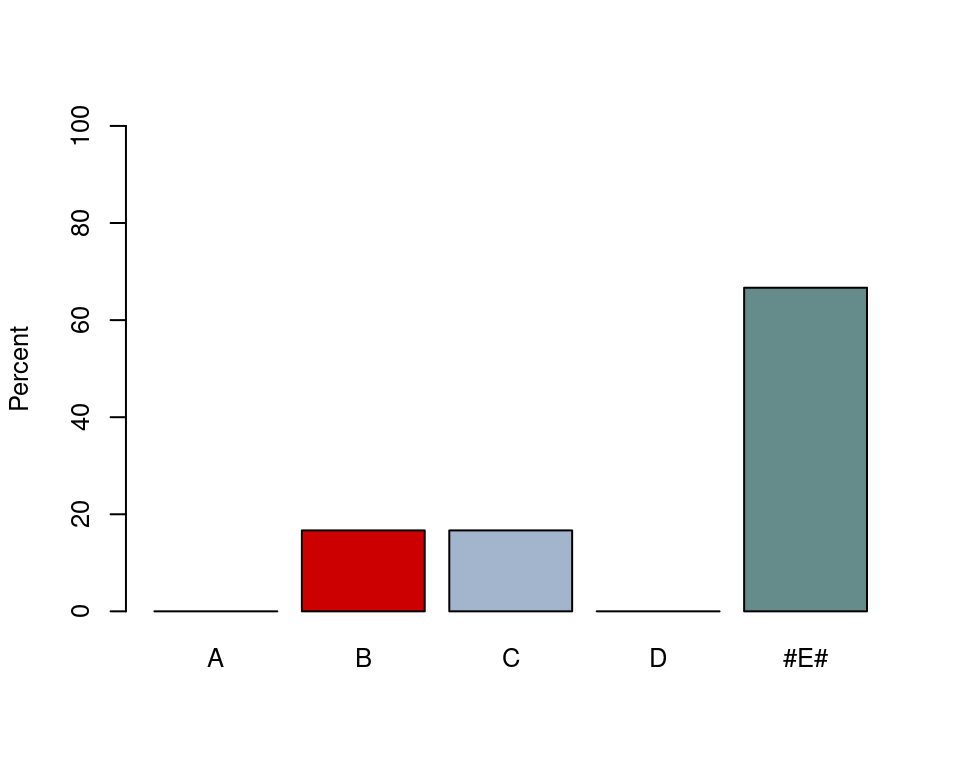

**Statistics for exam 25102300001; responses to Q.6**

| Response | Frequency | Percent | Biserial |
| --- | --- | --- | --- |
| A | 0 | 0.00 | NA |
| #B# | 4 | 66.67 | 0.39 |
| C | 1 | 16.67 | -0.67 |
| D | 1 | 16.67 | 0.17 |
| Total | 6 | 100.01 | NA |

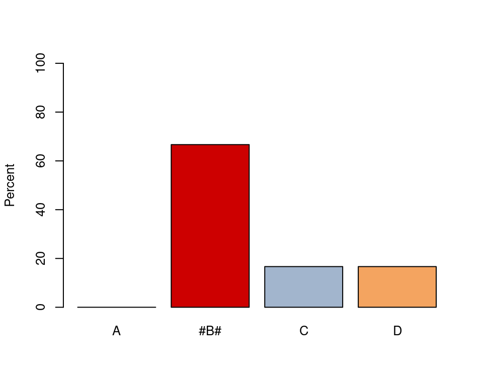

**Statistics for exam 25102300001; responses to Q.7**

| Response | Frequency | Percent | Biserial |
| --- | --- | --- | --- |
| A | 1 | 16.67 | -0.52 |
| B | 1 | 16.67 | 0.17 |
| #C# | 2 | 33.33 | 0.66 |
| D | 2 | 33.33 | -0.39 |
| Total | 6 | 100.00 | NA |

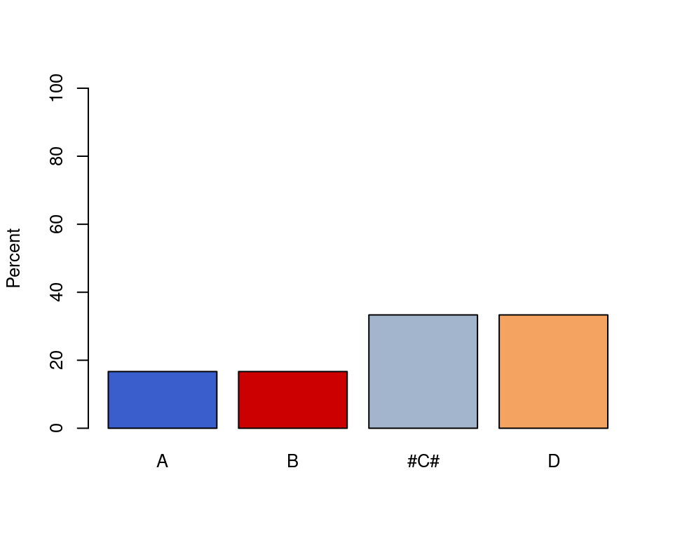

**Statistics for exam 25102300001; responses to Q.8**

| Response | Frequency | Percent | Biserial |
| --- | --- | --- | --- |
| A | 1 | 16.67 | 0.22 |
| B | 2 | 33.33 | -0.27 |
| #C# | 1 | 16.67 | 0.62 |
| D | 2 | 33.33 | -0.39 |
| Total | 6 | 100.00 | NA |

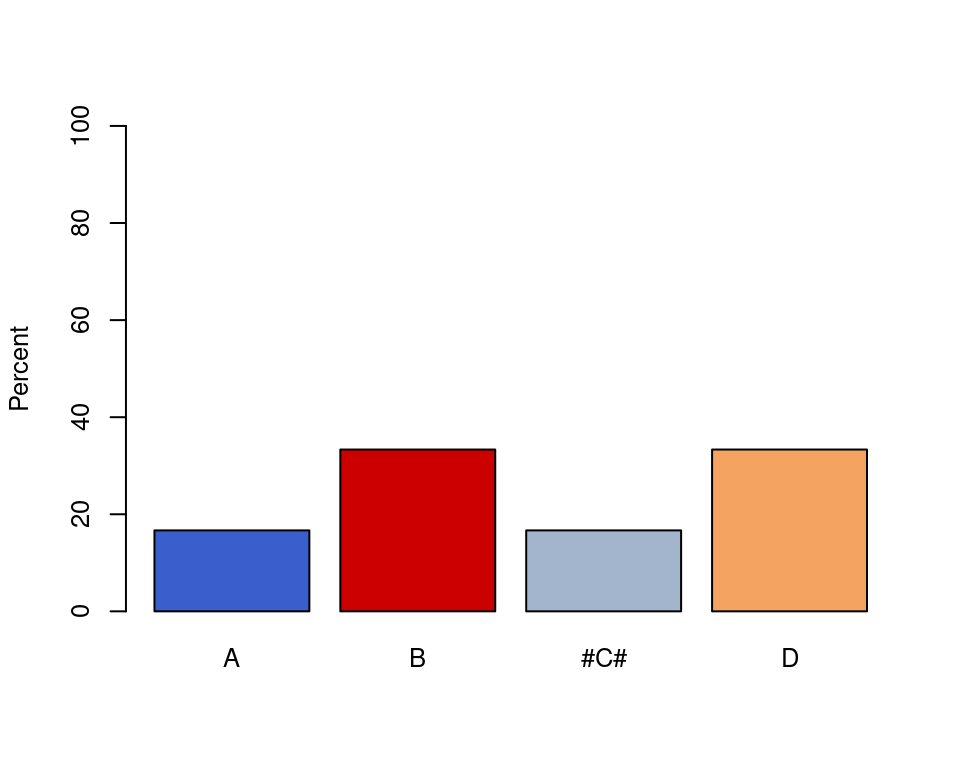

**Statistics for exam 25102300001; responses to Q.9**

| Response | Frequency | Percent | Biserial |
| --- | --- | --- | --- |
| A | 2 | 33.33 | -0.35 |
| B | 1 | 16.67 | 0.17 |
| C | 1 | 16.67 | -0.52 |
| #D# | 2 | 33.33 | 0.62 |
| Total | 6 | 100.00 | NA |

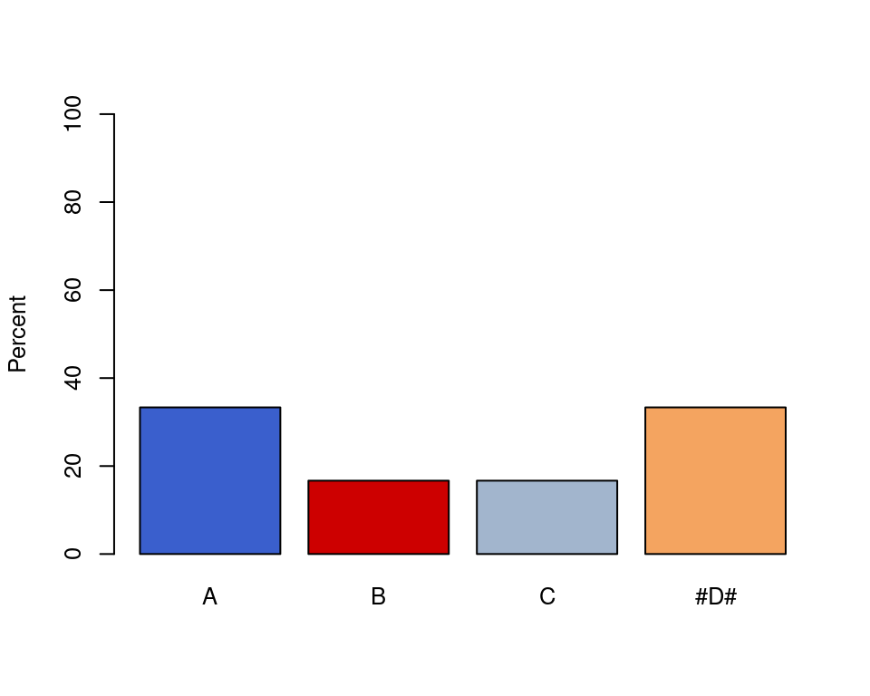

**Statistics for exam 25102300001; responses to Q.10**

| Response | Frequency | Percent | Biserial |
| --- | --- | --- | --- |
| A | 1 | 16.67 | 0.22 |
| B | 3 | 50.00 | -0.75 |
| C | 1 | 16.67 | 0.17 |
| #D# | 1 | 16.67 | 0.62 |
| Total | 6 | 100.01 | NA |

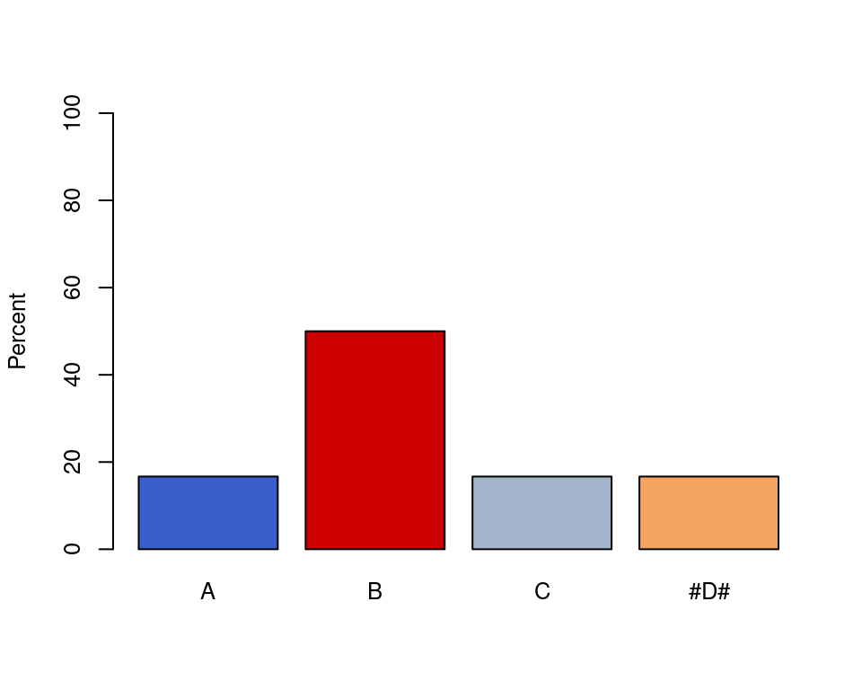

**Statistics for exam 25102300001; responses to Q.11**

| Response | Frequency | Percent | Biserial |
| --- | --- | --- | --- |
| A | 0 | 0.00 | NA |
| #B# | 5 | 83.33 | 0.67 |
| C | 1 | 16.67 | -0.67 |
| D | 0 | 0.00 | NA |
| Total | 6 | 100.00 | NA |

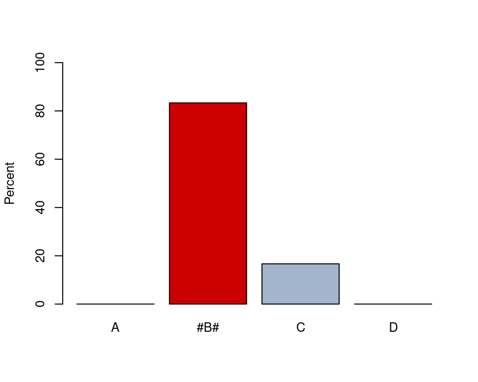

**Statistics for exam 25102300001; responses to Q.12**

| Response | Frequency | Percent | Biserial |
| --- | --- | --- | --- |
| A | 0 | 0.00 | NA |
| B | 1 | 16.67 | -0.67 |
| C | 1 | 16.67 | 0.17 |
| #D# | 4 | 66.67 | 0.39 |
| Total | 6 | 100.01 | NA |

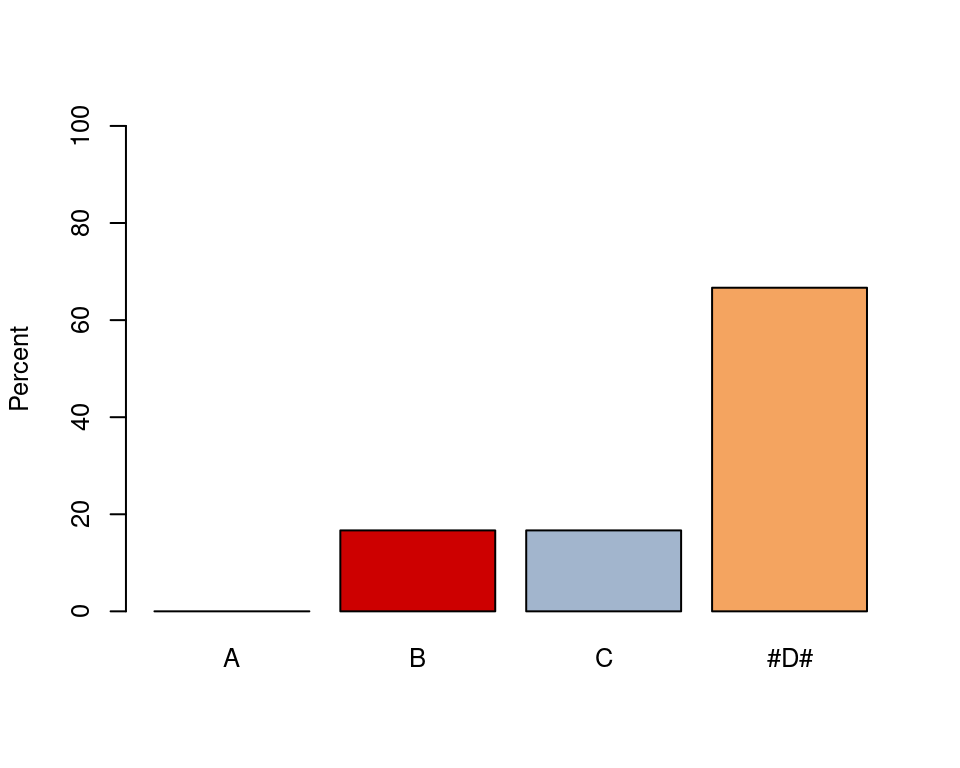

**Statistics for exam 25102300001; responses to Q.13**

| Response | Frequency | Percent | Biserial |
| --- | --- | --- | --- |
| A | 0 | 0.00 | NA |
| #B# | 4 | 66.67 | 0.94 |
| C | 1 | 16.67 | -0.52 |
| D | 1 | 16.67 | -0.67 |
| Total | 6 | 100.01 | NA |

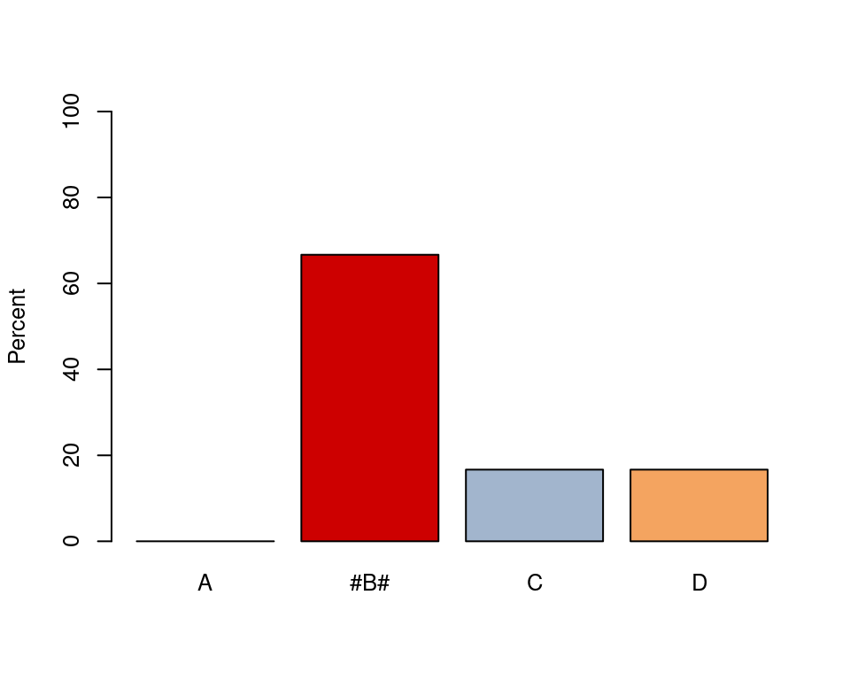

**Statistics for exam 25102300001; responses to Q.14**

| Response | Frequency | Percent | Biserial |
| --- | --- | --- | --- |
| A | 1 | 8.33 | -0.52 |
| #B# | 5 | 41.67 | 0.67 |
| C | 1 | 8.33 | -0.67 |
| #D# | 3 | 25.00 | 0.75 |
| E | 2 | 16.67 | -0.94 |
| Total | 12 | 100.00 | NA |

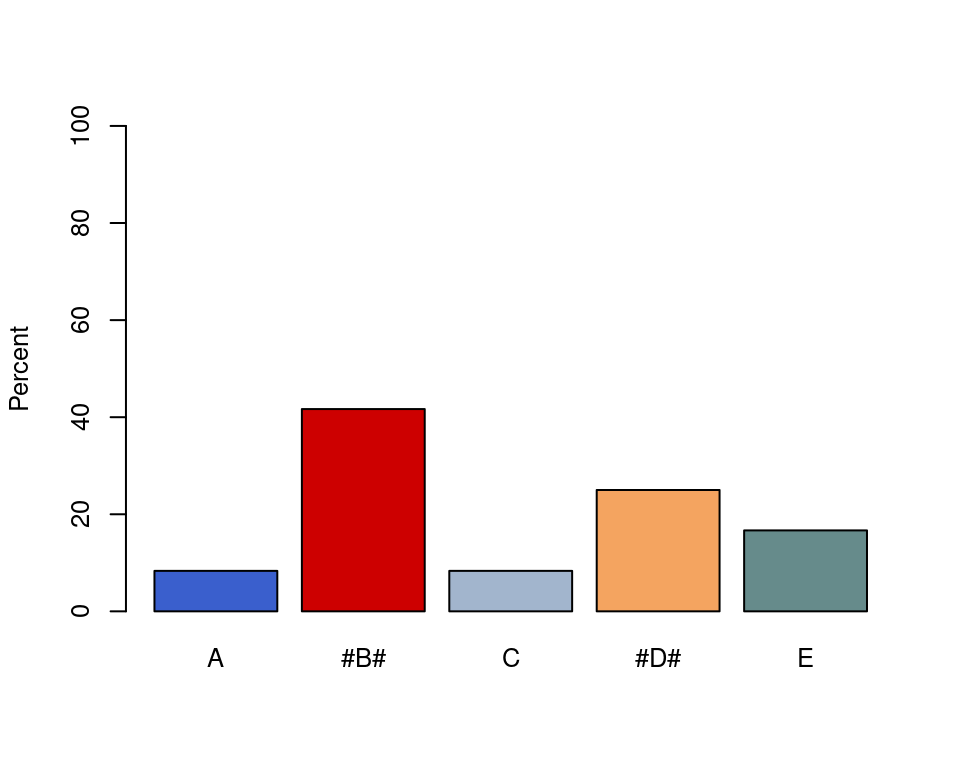

**Statistics for exam 25102300001; responses to Q.15**

| Response | Frequency | Percent | Biserial |
| --- | --- | --- | --- |
| A | 1 | 8.33 | -0.52 |
| #B# | 5 | 41.67 | 0.52 |
| #C# | 6 | 50.00 | NA |
| D | 0 | 0.00 | NA |
| E | 0 | 0.00 | NA |
| Total | 12 | 100.00 | NA |

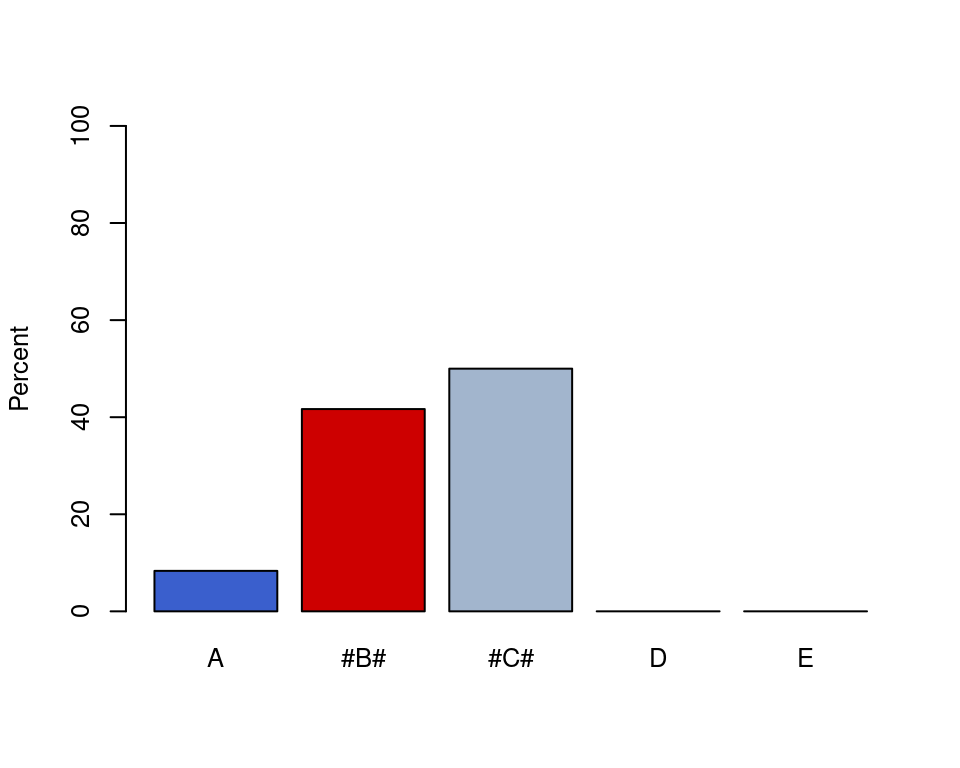

**Statistics for exam 25102300001; responses to Q.16**

| Response | Frequency | Percent | Biserial |
| --- | --- | --- | --- |
| #A# | 5 | 83.33 | -0.22 |
| B | 1 | 16.67 | 0.22 |
| Total | 6 | 100.00 | NA |

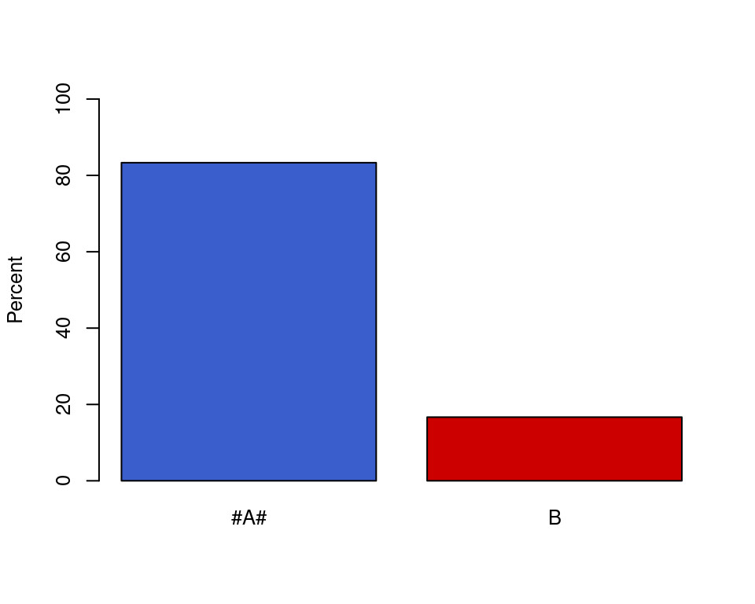

**Statistics for exam 25102300001; responses to Q.17**

| Response | Frequency | Percent | Biserial |
| --- | --- | --- | --- |
| #A# | 3 | 50 | 0.75 |
| B | 3 | 50 | -0.75 |
| Total | 6 | 100 | NA |

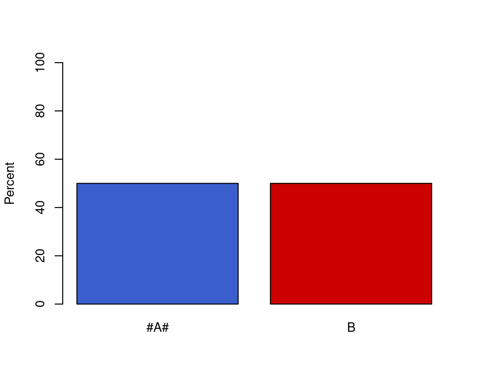

**Statistics for exam 25102300001; responses to Q.18**

| Response | Frequency | Percent | Biserial |
| --- | --- | --- | --- |
| #A# | 5 | 83.33 | 0.67 |
| B | 1 | 16.67 | -0.67 |
| C | 0 | 0.00 | NA |
| D | 0 | 0.00 | NA |
| Total | 6 | 100.00 | NA |

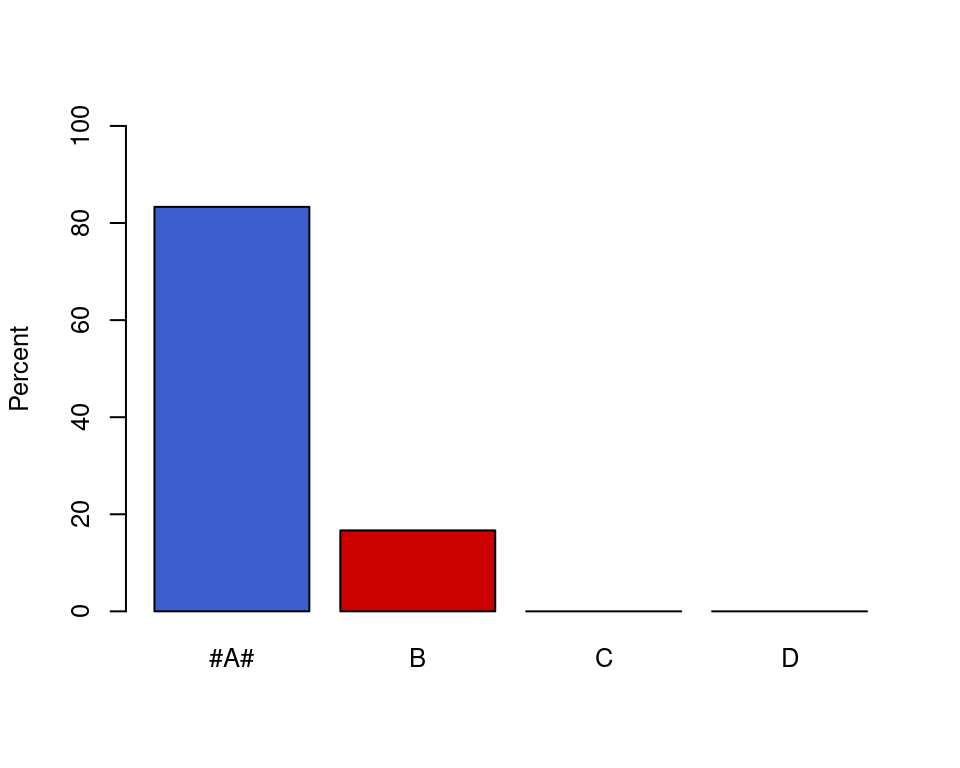

**Statistics for exam 25102300001; responses to Q.19**

| Response | Frequency | Percent | Biserial |
| --- | --- | --- | --- |
| A | 0 | 0.00 | NA |
| #B# | 5 | 83.33 | 0.52 |
| C | 1 | 16.67 | -0.52 |
| D | 0 | 0.00 | NA |
| Total | 6 | 100.00 | NA |

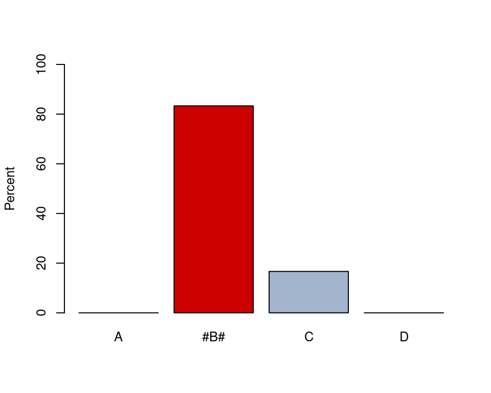

**Statistics for exam 25102300001; responses to Q.20**

| Response | Frequency | Percent | Biserial |
| --- | --- | --- | --- |
| A | 1 | 16.67 | -0.67 |
| B | 2 | 33.33 | -0.23 |
| #C# | 3 | 50.00 | 0.72 |
| D | 0 | 0.00 | NA |
| Total | 6 | 100.00 | NA |

**Statistics for exam 25102300001; responses to Q.21**

| Response | Frequency | Percent | Biserial |
| --- | --- | --- | --- |
| A | 2 | 33.33 | -0.27 |
| B | 1 | 16.67 | -0.67 |
| #C# | 3 | 50.00 | 0.75 |
| D | 0 | 0.00 | NA |
| Total | 6 | 100.00 | NA |

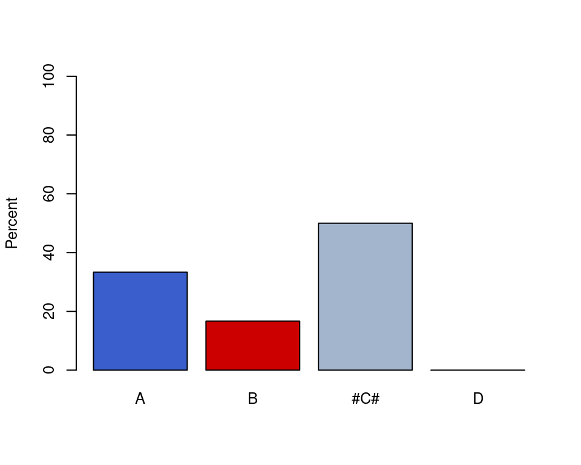

**Statistics for exam 25102300001; responses to Q.22**

| Response | Frequency | Percent | Biserial |
| --- | --- | --- | --- |
| A | 1 | 16.67 | -0.67 |
| B | 2 | 33.33 | -0.27 |
| #C# | 3 | 50.00 | 0.75 |
| D | 0 | 0.00 | NA |
| Total | 6 | 100.00 | NA |

**Statistics for exam 25102300001; responses to Q.23**

| Response | Frequency | Percent | Biserial |
| --- | --- | --- | --- |
| A | 2 | 33.33 | -0.94 |
| B | 1 | 16.67 | 0.17 |
| C | 0 | 0.00 | NA |
| #D# | 3 | 50.00 | 0.75 |
| Total | 6 | 100.00 | NA |

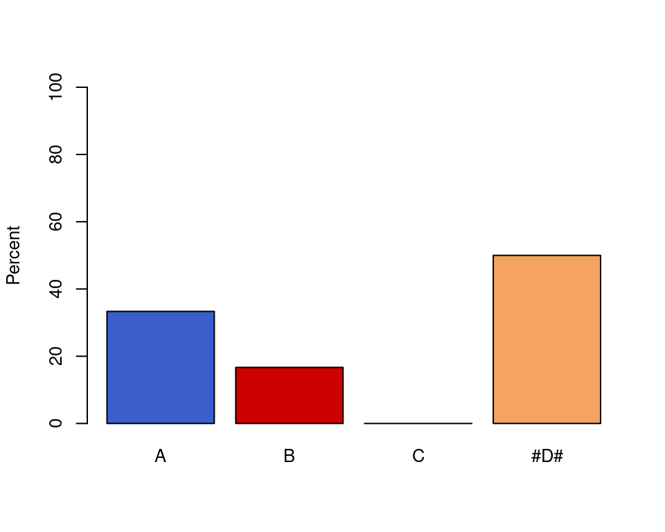

**Statistics for exam 25102300001; responses to Q.24**

| Response | Frequency | Percent | Biserial |
| --- | --- | --- | --- |
| A | 0 | 0.00 | NA |
| B | 2 | 33.33 | -0.27 |
| C | 0 | 0.00 | NA |
| #D# | 4 | 66.67 | 0.27 |
| Total | 6 | 100.00 | NA |

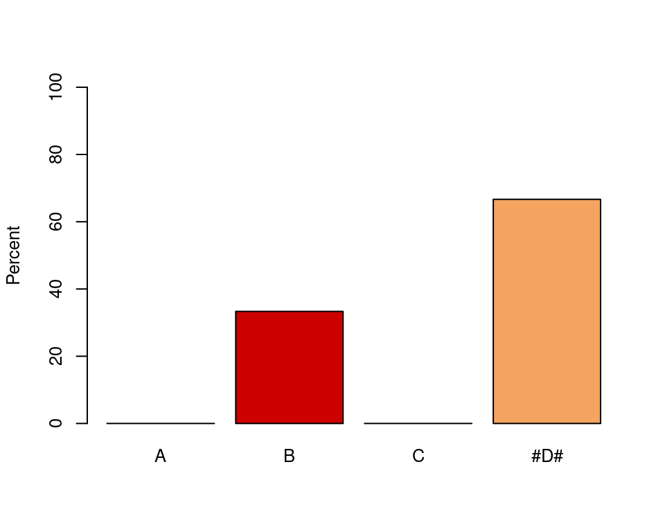

**Statistics for exam 25102300001; responses to Q.25**

| Response | Frequency | Percent | Biserial |
| --- | --- | --- | --- |
| #A# | 3 | 60 | 0.72 |
| B | 1 | 20 | -0.67 |
| C | 1 | 20 | -0.52 |
| D | 0 | 0 | NA |
| Total | 5 | 100 | NA |

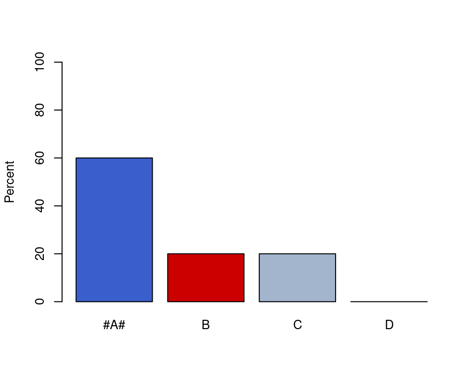

**Statistics for exam 25102300001; responses to Q.26**

| Response | Frequency | Percent | Biserial |
| --- | --- | --- | --- |
| A | 1 | 16.67 | 0.22 |
| B | 2 | 33.33 | -0.94 |
| C | 0 | 0.00 | NA |
| D | 0 | 0.00 | NA |
| #E# | 3 | 50.00 | 0.72 |
| Total | 6 | 100.00 | NA |

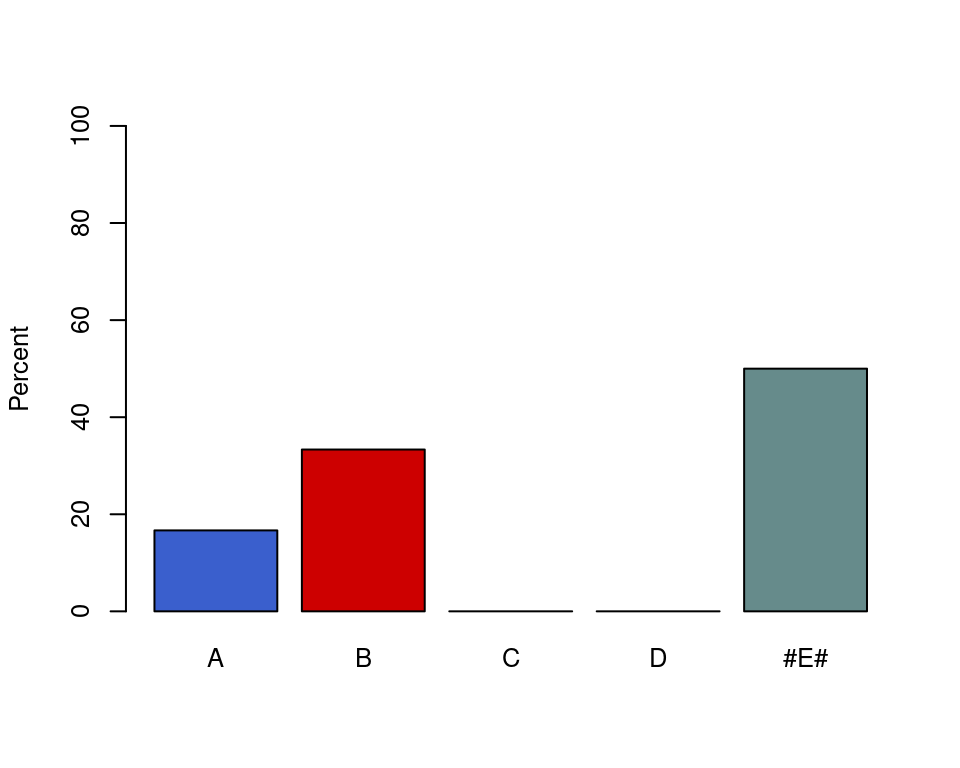

**Statistics for exam 25102300001; responses to Q.27**

| Response | Frequency | Percent | Biserial |
| --- | --- | --- | --- |
| #A# | 3 | 50.00 | 0.75 |
| B | 0 | 0.00 | NA |
| C | 2 | 33.33 | -0.39 |
| D | 1 | 16.67 | -0.52 |
| Total | 6 | 100.00 | NA |

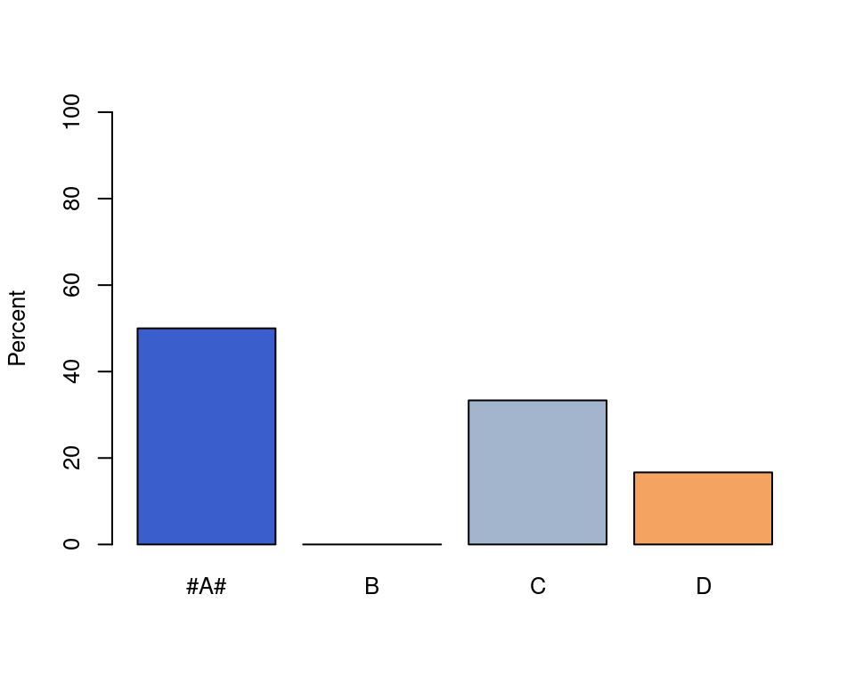

**Statistics for exam 25102300001; responses to Q.28**

| Response | Frequency | Percent | Biserial |
| --- | --- | --- | --- |
| A | 0 | 0.00 | NA |
| B | 2 | 33.33 | -0.39 |
| #C# | 4 | 66.67 | 0.39 |
| D | 0 | 0.00 | NA |
| Total | 6 | 100.00 | NA |

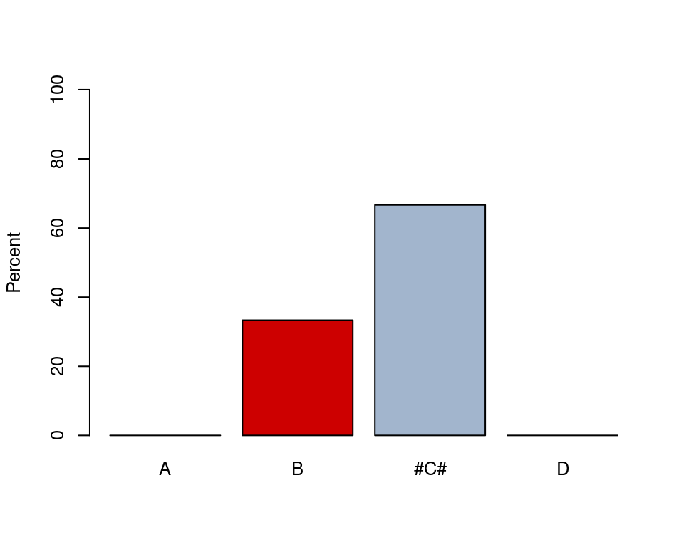

**Statistics for exam 25102300001; responses to Q.29**

| Response | Frequency | Percent | Biserial |
| --- | --- | --- | --- |
| A | 0 | 0.00 | NA |
| B | 1 | 16.67 | -0.52 |
| C | 2 | 33.33 | -0.39 |
| #D# | 3 | 50.00 | 0.75 |
| Total | 6 | 100.00 | NA |

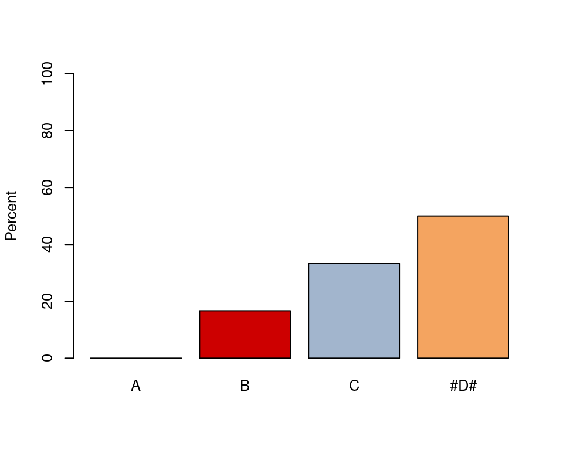

**Statistics for exam 25102300001; responses to Q.30**

| Response | Frequency | Percent | Biserial |
| --- | --- | --- | --- |
| #A# | 5 | 83.33 | 0.67 |
| B | 1 | 16.67 | -0.67 |
| C | 0 | 0.00 | NA |
| D | 0 | 0.00 | NA |
| Total | 6 | 100.00 | NA |

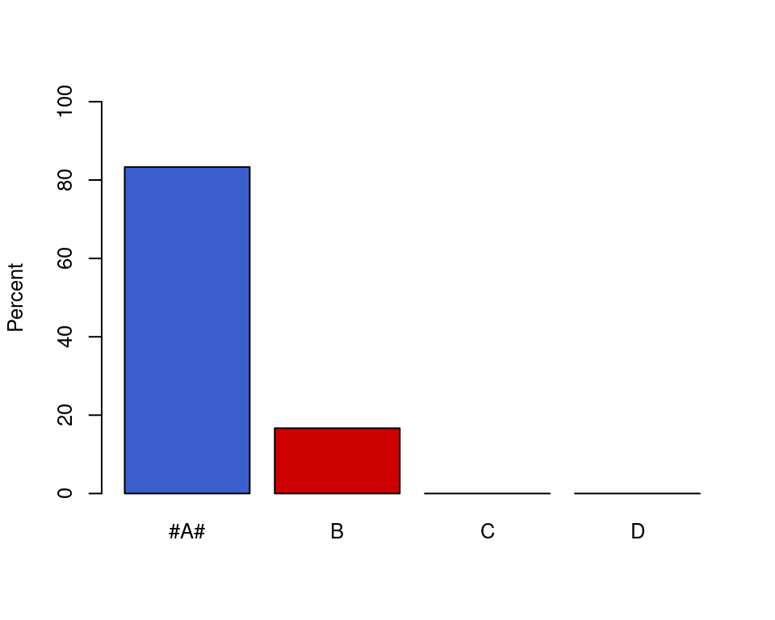

### Exam: 25102300002

**Statistics for exam 25102300002; responses to Q.1**

| Response | Frequency | Percent | Biserial |
| --- | --- | --- | --- |
| #A# | 5 | 83.33 | 0.52 |
| B | 1 | 16.67 | -0.52 |
| C | 0 | 0.00 | NA |
| D | 0 | 0.00 | NA |
| E | 0 | 0.00 | NA |
| Total | 6 | 100.00 | NA |

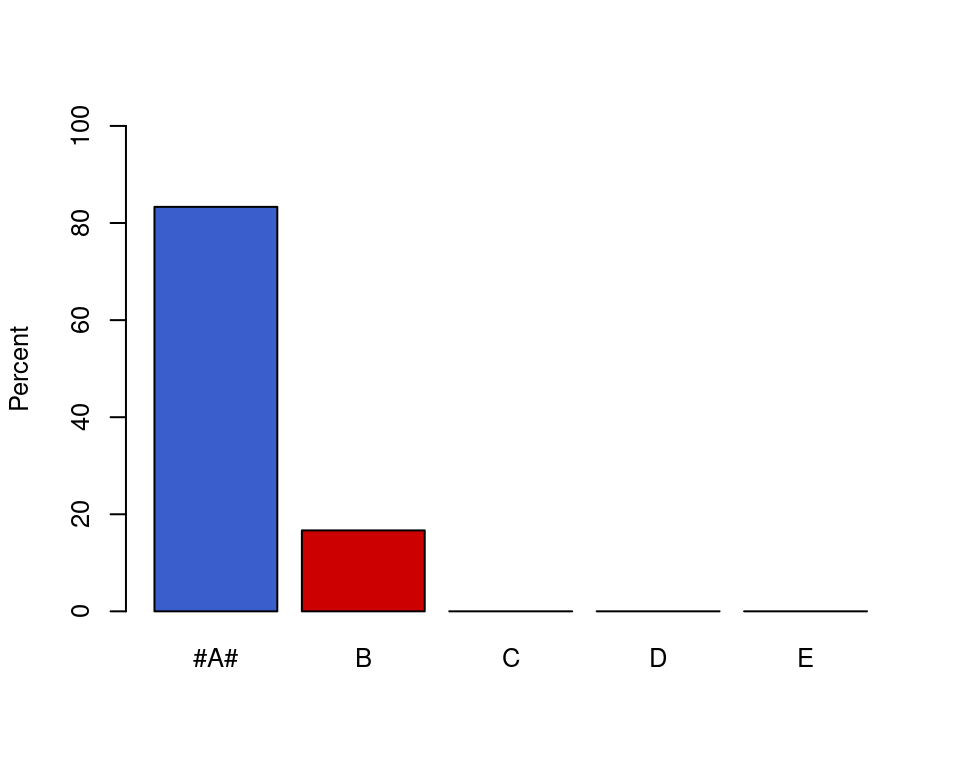

**Statistics for exam 25102300002; responses to Q.2**

| Response | Frequency | Percent | Biserial |
| --- | --- | --- | --- |
| A | 3 | 50 | -0.46 |
| B | 0 | 0 | NA |
| C | 0 | 0 | NA |
| #D# | 3 | 50 | 0.46 |
| E | 0 | 0 | NA |
| Total | 6 | 100 | NA |

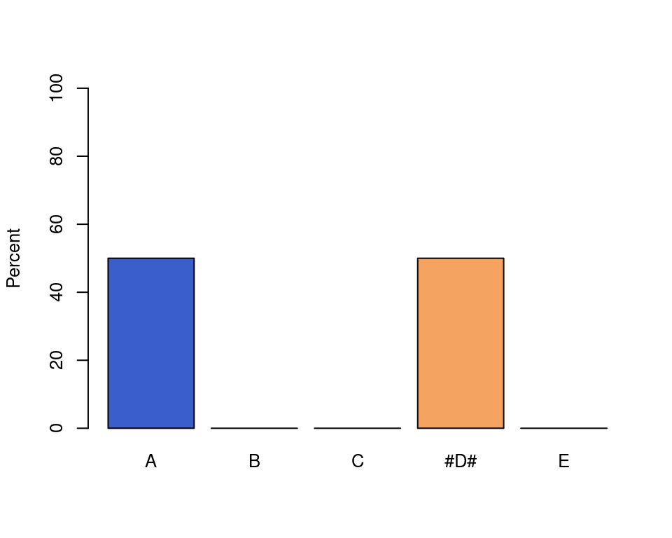

**Statistics for exam 25102300002; responses to Q.3**

| Response | Frequency | Percent | Biserial |
| --- | --- | --- | --- |
| A | 5 | 83.33 | 0.52 |
| #B# | 0 | 0.00 | NA |
| C | 0 | 0.00 | NA |
| D | 0 | 0.00 | NA |
| E | 1 | 16.67 | -0.52 |
| Total | 6 | 100.00 | NA |

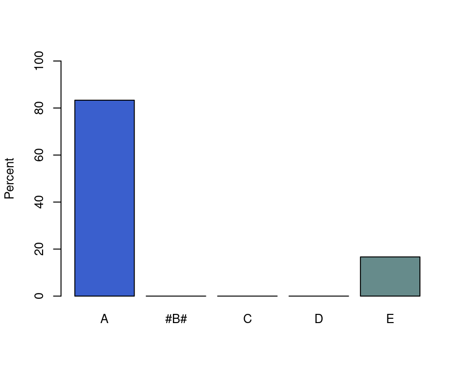

**Statistics for exam 25102300002; responses to Q.4**

| Response | Frequency | Percent | Biserial |
| --- | --- | --- | --- |
| A | 0 | 0.00 | NA |
| B | 1 | 16.67 | 0.50 |
| #C# | 3 | 50.00 | 0.46 |
| D | 1 | 16.67 | -0.52 |
| E | 1 | 16.67 | -0.59 |
| Total | 6 | 100.01 | NA |

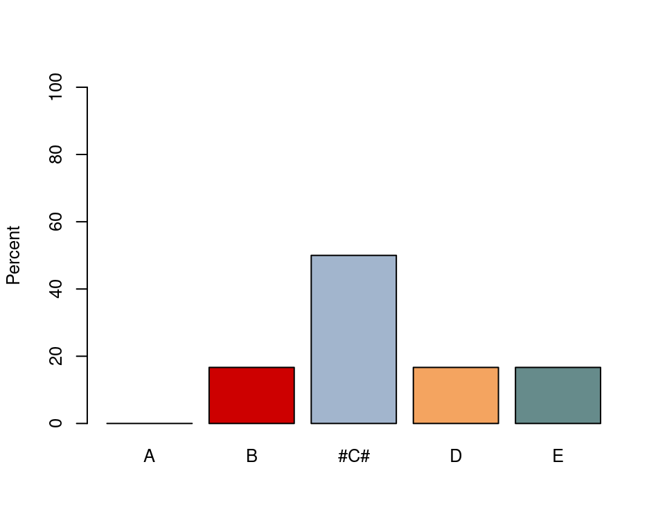

**Statistics for exam 25102300002; responses to Q.5**

| Response | Frequency | Percent | Biserial |
| --- | --- | --- | --- |
| A | 0 | 0.00 | NA |
| B | 0 | 0.00 | NA |
| C | 0 | 0.00 | NA |
| #D# | 4 | 66.67 | 0.88 |
| E | 2 | 33.33 | -0.88 |
| Total | 6 | 100.00 | NA |

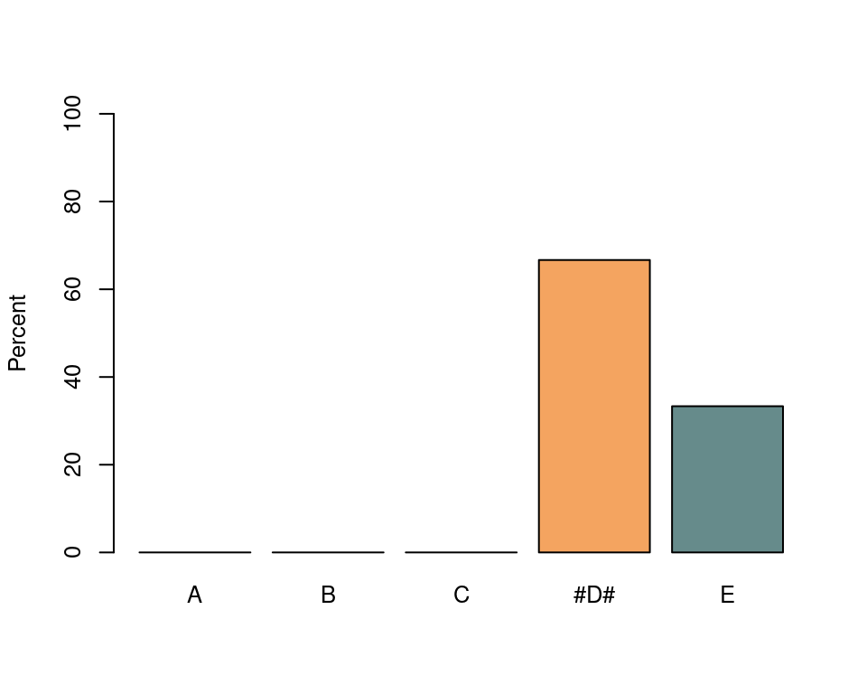

**Statistics for exam 25102300002; responses to Q.6**

| Response | Frequency | Percent | Biserial |
| --- | --- | --- | --- |
| A | 1 | 16.67 | 0.02 |
| #B# | 2 | 33.33 | -0.07 |
| C | 1 | 16.67 | -0.52 |
| D | 2 | 33.33 | 0.47 |
| Total | 6 | 100.00 | NA |

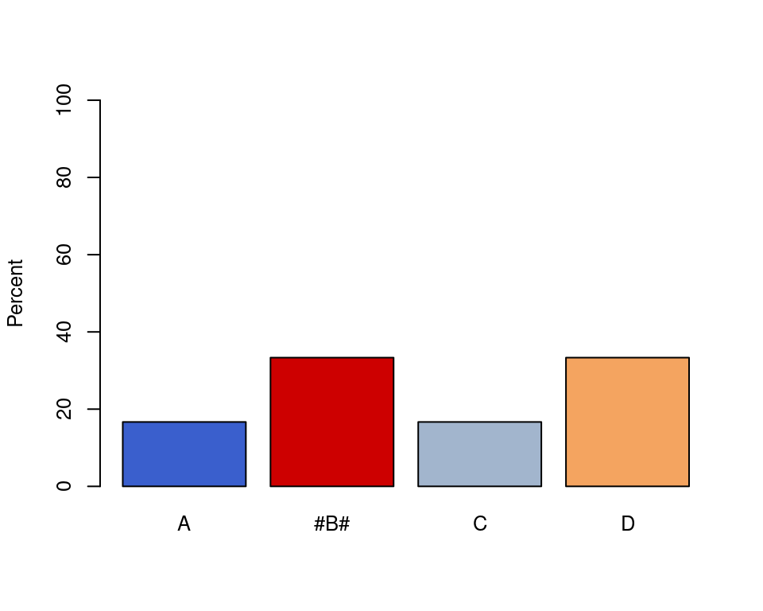

**Statistics for exam 25102300002; responses to Q.7**

| Response | Frequency | Percent | Biserial |
| --- | --- | --- | --- |
| A | 0 | 0 | NA |
| B | 3 | 50 | -0.81 |
| #C# | 3 | 50 | 0.81 |
| D | 0 | 0 | NA |
| Total | 6 | 100 | NA |

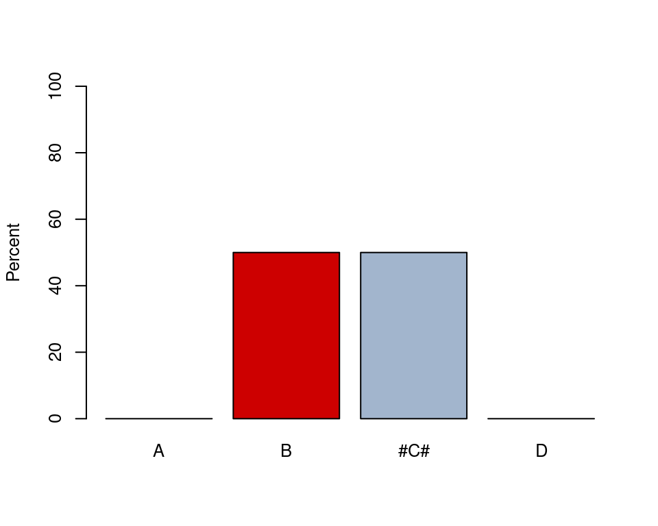

**Statistics for exam 25102300002; responses to Q.8**

| Response | Frequency | Percent | Biserial |
| --- | --- | --- | --- |
| A | 1 | 20 | -0.59 |
| B | 1 | 20 | 0.02 |
| C | 1 | 20 | -0.52 |
| #D# | 2 | 40 | 0.85 |
| Total | 5 | 100 | NA |

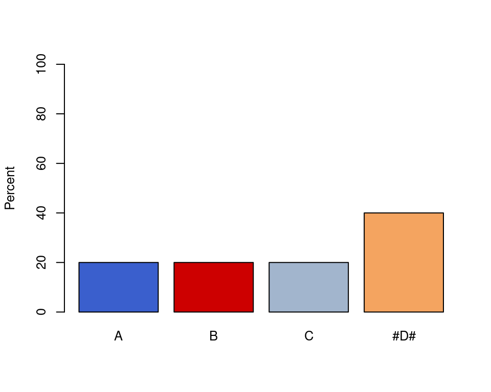

**Statistics for exam 25102300002; responses to Q.9**

| Response | Frequency | Percent | Biserial |
| --- | --- | --- | --- |
| A | 2 | 33.33 | 0.04 |
| B | 0 | 0.00 | NA |
| C | 2 | 33.33 | -0.02 |
| #D# | 2 | 33.33 | -0.02 |
| Total | 6 | 99.99 | NA |

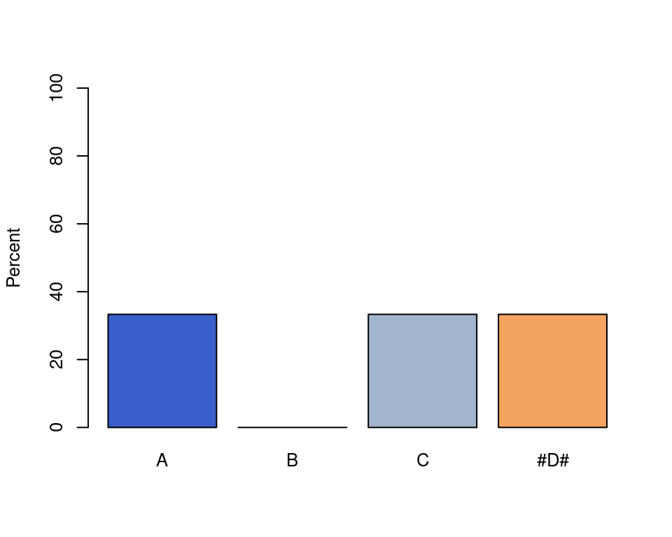

**Statistics for exam 25102300002; responses to Q.10**

| Response | Frequency | Percent | Biserial |
| --- | --- | --- | --- |
| #A# | 1 | 16.67 | -0.52 |
| B | 4 | 66.67 | 0.40 |
| C | 0 | 0.00 | NA |
| D | 1 | 16.67 | 0.02 |
| Total | 6 | 100.01 | NA |

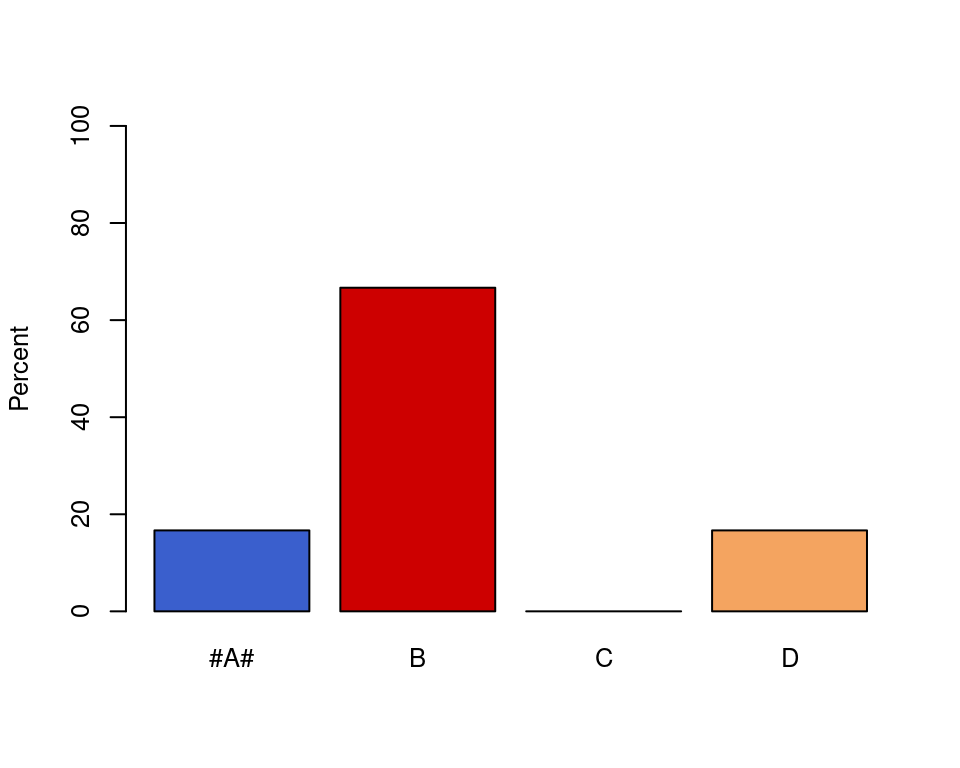

**Statistics for exam 25102300002; responses to Q.11**

| Response | Frequency | Percent | Biserial |
| --- | --- | --- | --- |
| A | 0 | 0.00 | NA |
| B | 2 | 33.33 | -0.88 |
| #C# | 4 | 66.67 | 0.88 |
| D | 0 | 0.00 | NA |
| Total | 6 | 100.00 | NA |

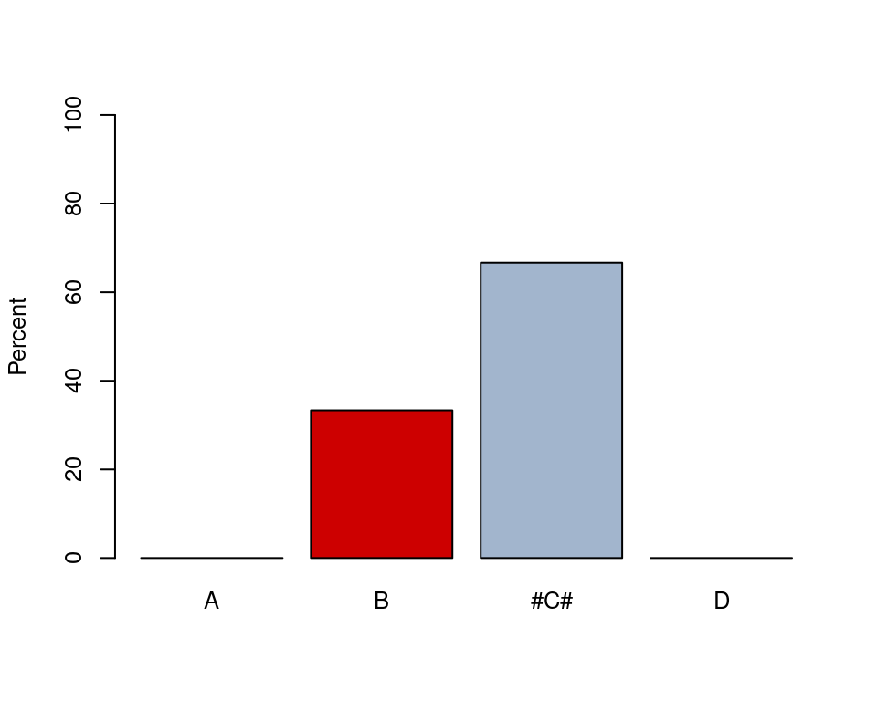

**Statistics for exam 25102300002; responses to Q.12**

| Response | Frequency | Percent | Biserial |
| --- | --- | --- | --- |
| A | 0 | 0.00 | NA |
| B | 0 | 0.00 | NA |
| C | 2 | 33.33 | -0.88 |
| #D# | 4 | 66.67 | 0.88 |
| Total | 6 | 100.00 | NA |

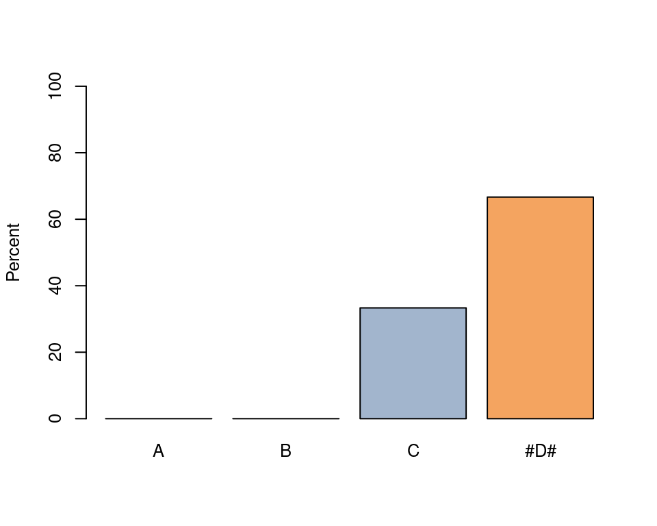

**Statistics for exam 25102300002; responses to Q.13**

| Response | Frequency | Percent | Biserial |
| --- | --- | --- | --- |
| A | 1 | 16.67 | -0.52 |
| B | 1 | 16.67 | -0.59 |
| #C# | 4 | 66.67 | 0.88 |
| D | 0 | 0.00 | NA |
| Total | 6 | 100.01 | NA |

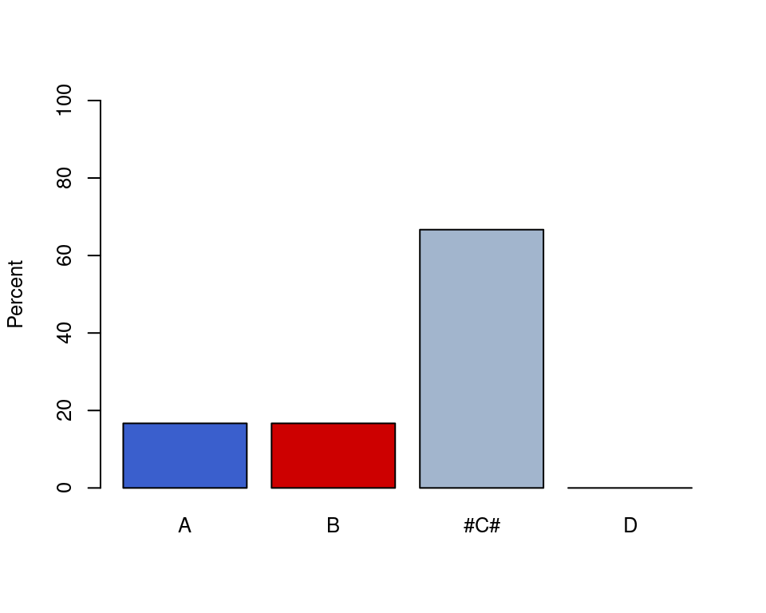

**Statistics for exam 25102300002; responses to Q.14**

| Response | Frequency | Percent | Biserial |
| --- | --- | --- | --- |
| #A# | 3 | 23.08 | -0.81 |
| B | 1 | 7.69 | 0.57 |
| C | 4 | 30.77 | 0.45 |
| #D# | 2 | 15.38 | 0.04 |
| #E# | 3 | 23.08 | -0.05 |
| Total | 13 | 100.00 | NA |

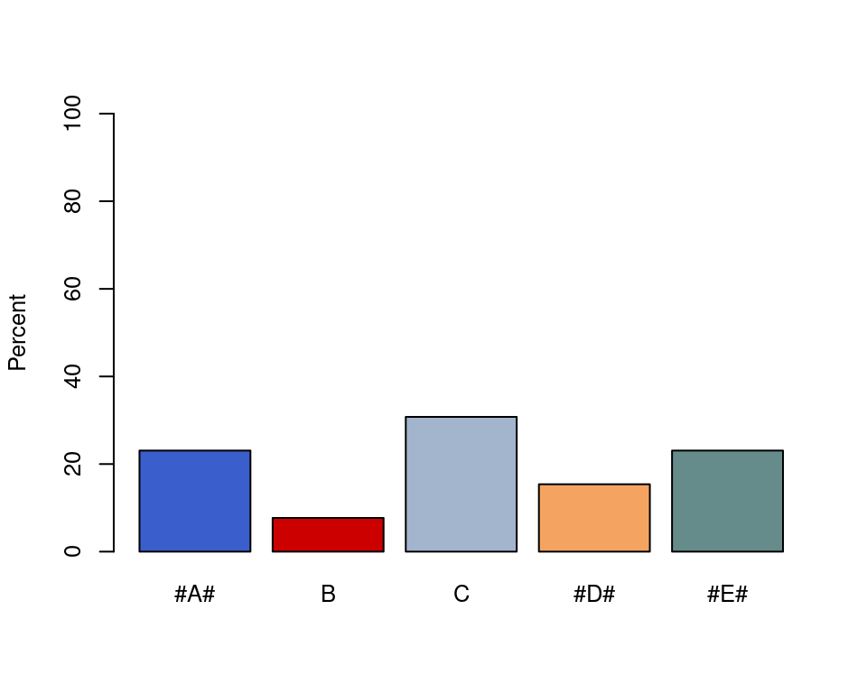

**Statistics for exam 25102300002; responses to Q.15**

| Response | Frequency | Percent | Biserial |
| --- | --- | --- | --- |
| A | 4 | 36.36 | 0.02 |
| #B# | 2 | 18.18 | -0.02 |
| C | 1 | 9.09 | -0.59 |
| D | 3 | 27.27 | 0.81 |
| E | 1 | 9.09 | -0.52 |
| Total | 11 | 99.99 | NA |

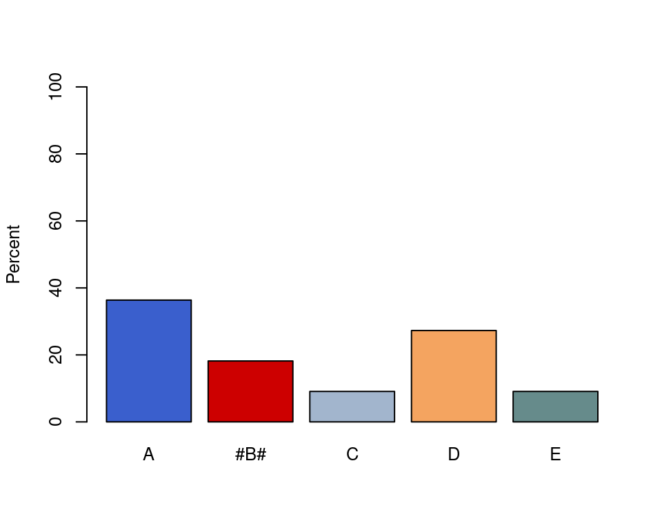

**Statistics for exam 25102300002; responses to Q.16**

| Response | Frequency | Percent | Biserial |
| --- | --- | --- | --- |
| A | 2 | 33.33 | -0.45 |
| #B# | 4 | 66.67 | 0.45 |
| Total | 6 | 100.00 | NA |

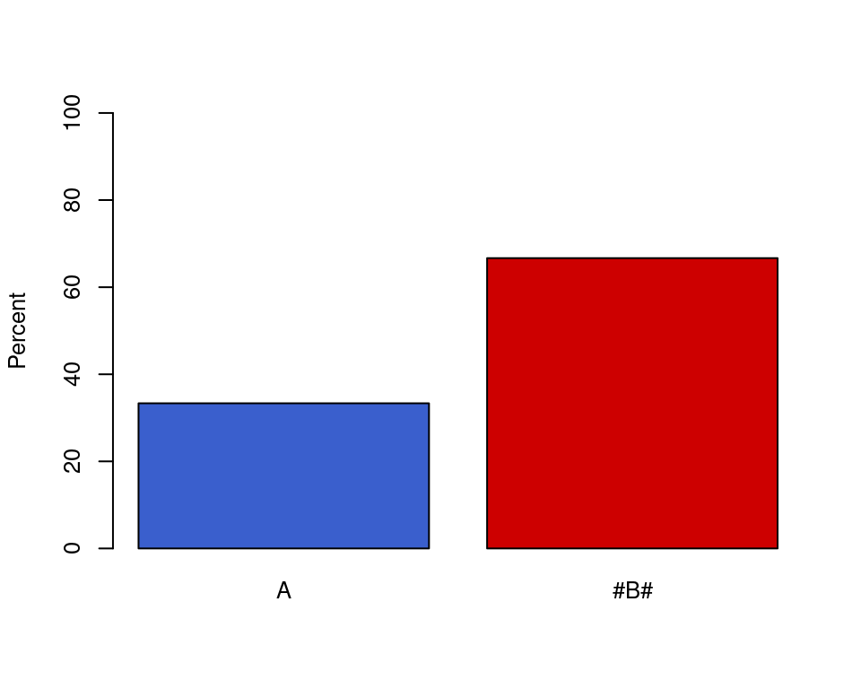

**Statistics for exam 25102300002; responses to Q.17**

| Response | Frequency | Percent | Biserial |
| --- | --- | --- | --- |
| A | 4 | 66.67 | -0.47 |
| #B# | 2 | 33.33 | 0.47 |
| Total | 6 | 100.00 | NA |

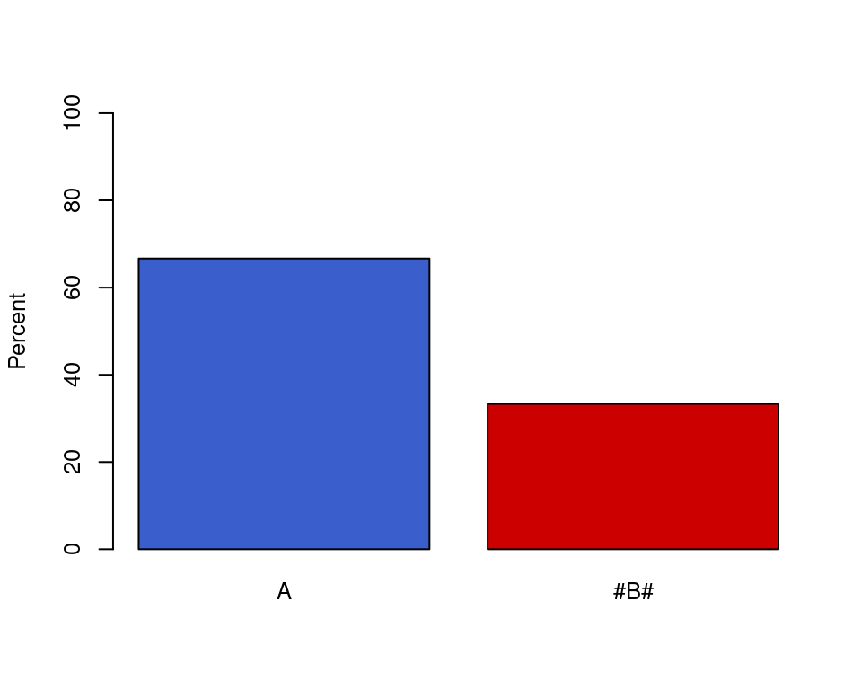

**Statistics for exam 25102300002; responses to Q.18**

| Response | Frequency | Percent | Biserial |
| --- | --- | --- | --- |
| A | 1 | 16.67 | 0.02 |
| B | 4 | 66.67 | -0.41 |
| #C# | 1 | 16.67 | 0.50 |
| D | 0 | 0.00 | NA |
| Total | 6 | 100.01 | NA |

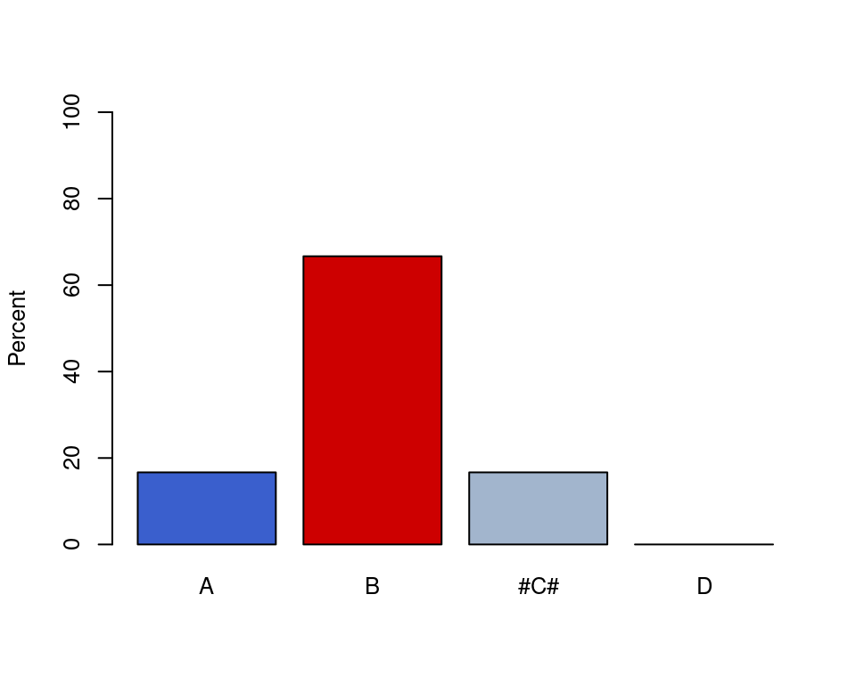

**Statistics for exam 25102300002; responses to Q.19**

| Response | Frequency | Percent | Biserial |
| --- | --- | --- | --- |
| A | 1 | 16.67 | -0.52 |
| B | 3 | 50.00 | 0.46 |
| #C# | 2 | 33.33 | -0.07 |
| D | 0 | 0.00 | NA |
| Total | 6 | 100.00 | NA |

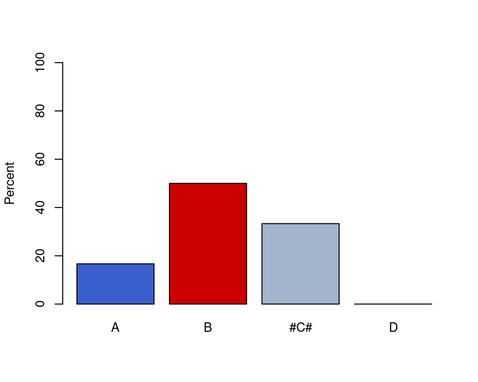

**Statistics for exam 25102300002; responses to Q.20**

| Response | Frequency | Percent | Biserial |
| --- | --- | --- | --- |
| A | 0 | 0.00 | NA |
| B | 1 | 16.67 | -0.59 |
| C | 1 | 16.67 | -0.52 |
| #D# | 4 | 66.67 | 0.88 |
| Total | 6 | 100.01 | NA |

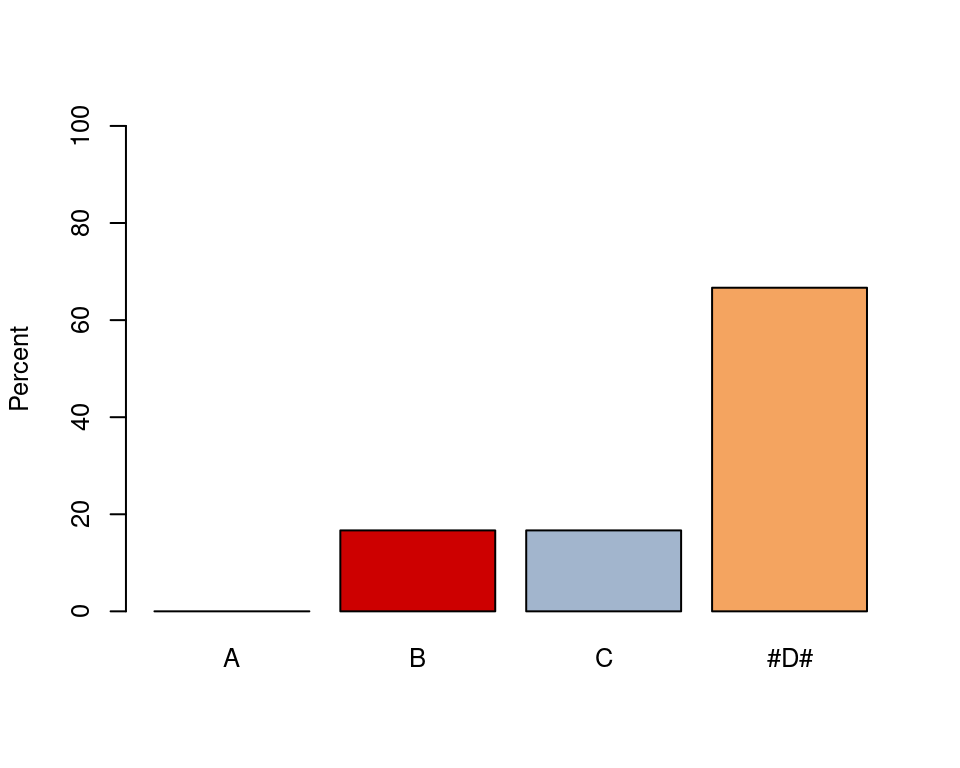

**Statistics for exam 25102300002; responses to Q.21**

| Response | Frequency | Percent | Biserial |
| --- | --- | --- | --- |
| A | 1 | 16.67 | -0.59 |
| #B# | 5 | 83.33 | 0.59 |
| C | 0 | 0.00 | NA |
| D | 0 | 0.00 | NA |
| Total | 6 | 100.00 | NA |

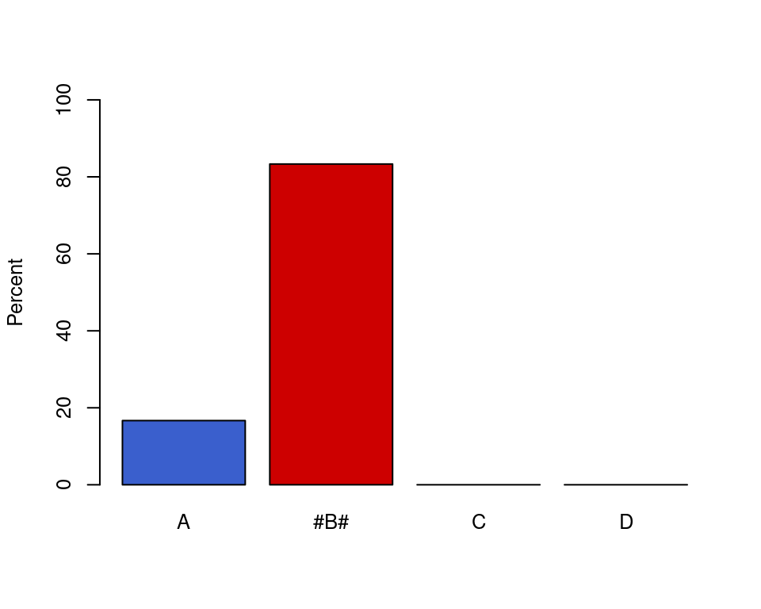

**Statistics for exam 25102300002; responses to Q.22**

| Response | Frequency | Percent | Biserial |
| --- | --- | --- | --- |
| A | 3 | 50.00 | -0.36 |
| #B# | 2 | 33.33 | 0.85 |
| C | 1 | 16.67 | -0.59 |
| D | 0 | 0.00 | NA |
| Total | 6 | 100.00 | NA |

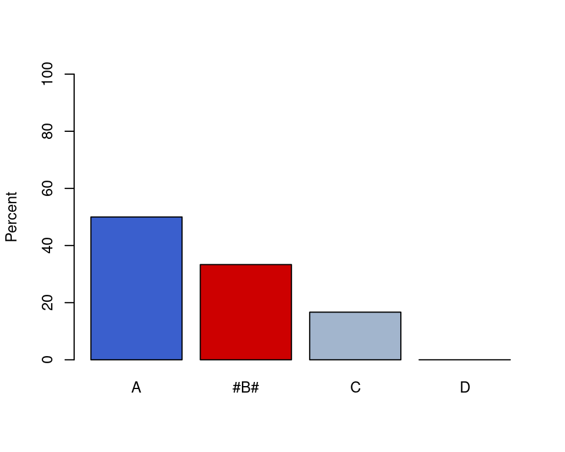

**Statistics for exam 25102300002; responses to Q.23**

| Response | Frequency | Percent | Biserial |
| --- | --- | --- | --- |
| A | 1 | 16.67 | -0.59 |
| B | 2 | 33.33 | 0.04 |
| #C# | 3 | 50.00 | 0.41 |
| D | 0 | 0.00 | NA |
| Total | 6 | 100.00 | NA |

**Statistics for exam 25102300002; responses to Q.24**

| Response | Frequency | Percent | Biserial |
| --- | --- | --- | --- |
| #A# | 3 | 50.00 | 0.41 |
| B | 1 | 16.67 | -0.59 |
| C | 2 | 33.33 | 0.04 |
| D | 0 | 0.00 | NA |
| Total | 6 | 100.00 | NA |

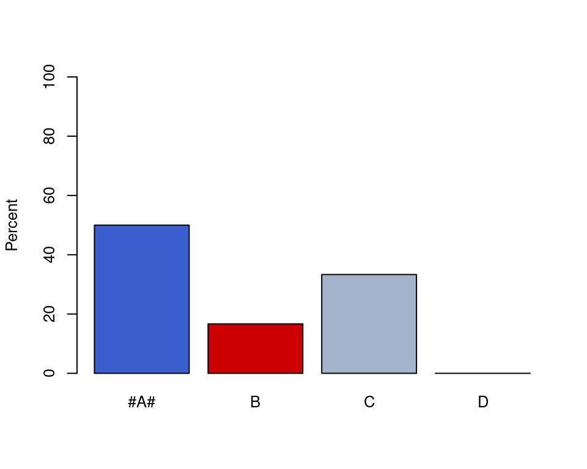

**Statistics for exam 25102300002; responses to Q.25**

| Response | Frequency | Percent | Biserial |
| --- | --- | --- | --- |
| #A# | 4 | 80 | 0.88 |
| B | 1 | 20 | -0.52 |
| C | 0 | 0 | NA |
| D | 0 | 0 | NA |
| Total | 5 | 100 | NA |

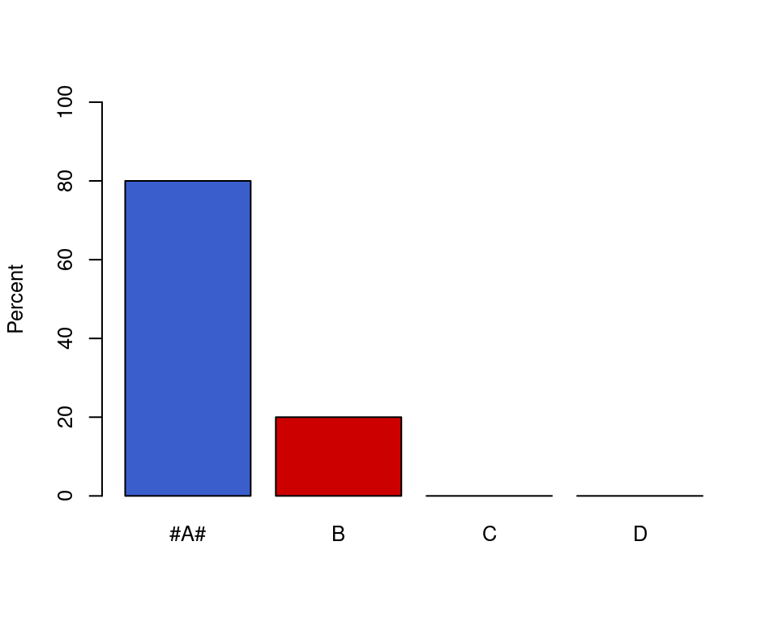

**Statistics for exam 25102300002; responses to Q.26**

| Response | Frequency | Percent | Biserial |
| --- | --- | --- | --- |
| A | 2 | 33.33 | -0.88 |
| B | 4 | 66.67 | 0.88 |
| C | 0 | 0.00 | NA |
| #D# | 0 | 0.00 | NA |
| E | 0 | 0.00 | NA |
| Total | 6 | 100.00 | NA |

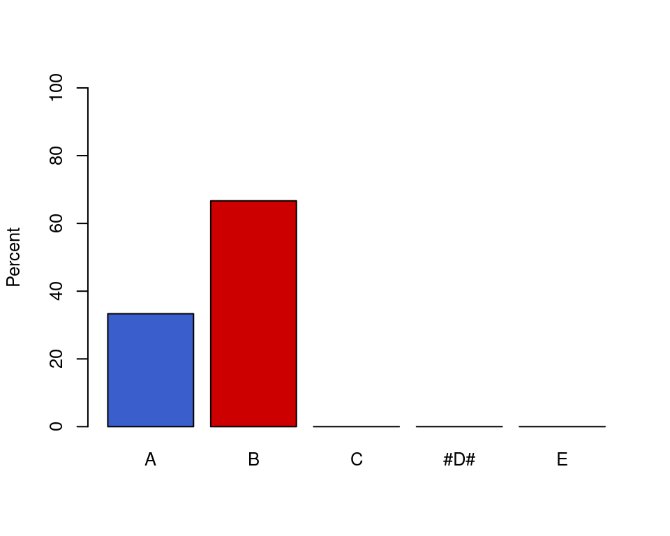

**Statistics for exam 25102300002; responses to Q.27**

| Response | Frequency | Percent | Biserial |
| --- | --- | --- | --- |
| #A# | 2 | 33.33 | 0.85 |
| B | 1 | 16.67 | -0.52 |
| C | 3 | 50.00 | -0.41 |
| D | 0 | 0.00 | NA |
| Total | 6 | 100.00 | NA |

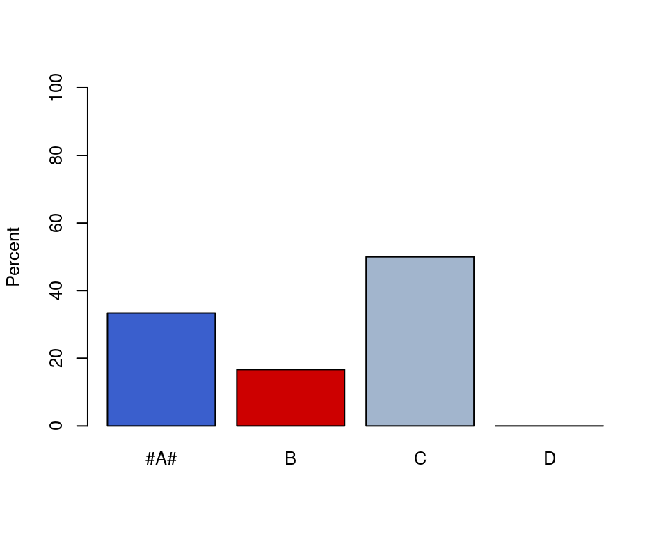

**Statistics for exam 25102300002; responses to Q.28**

| Response | Frequency | Percent | Biserial |
| --- | --- | --- | --- |
| A | 1 | 16.67 | -0.59 |
| B | 2 | 33.33 | 0.04 |
| C | 1 | 16.67 | -0.52 |
| #D# | 2 | 33.33 | 0.85 |
| Total | 6 | 100.00 | NA |

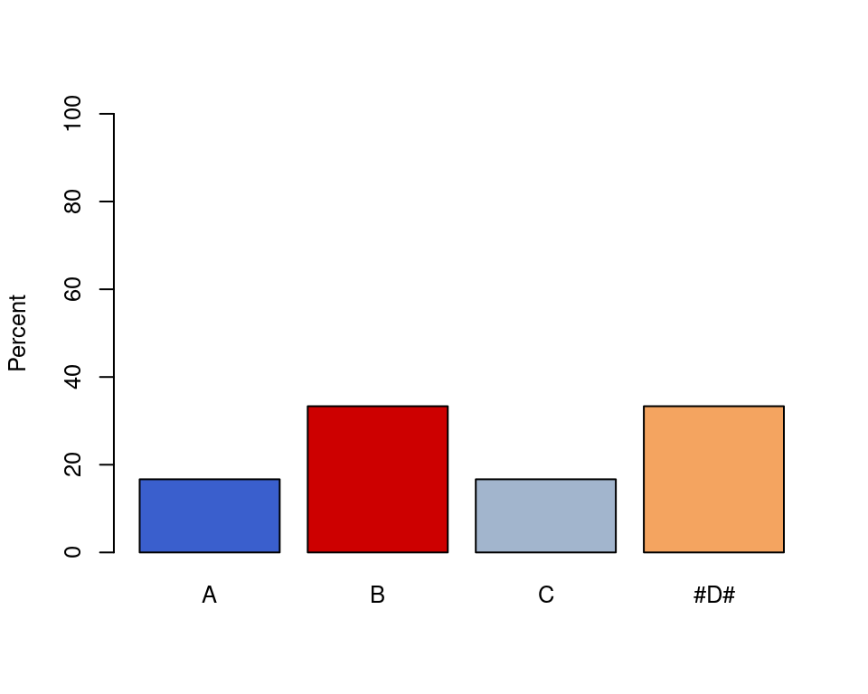

**Statistics for exam 25102300002; responses to Q.29**

| Response | Frequency | Percent | Biserial |
| --- | --- | --- | --- |
| A | 0 | 0.00 | NA |
| #B# | 5 | 83.33 | 0.59 |
| C | 0 | 0.00 | NA |
| D | 1 | 16.67 | -0.59 |
| Total | 6 | 100.00 | NA |

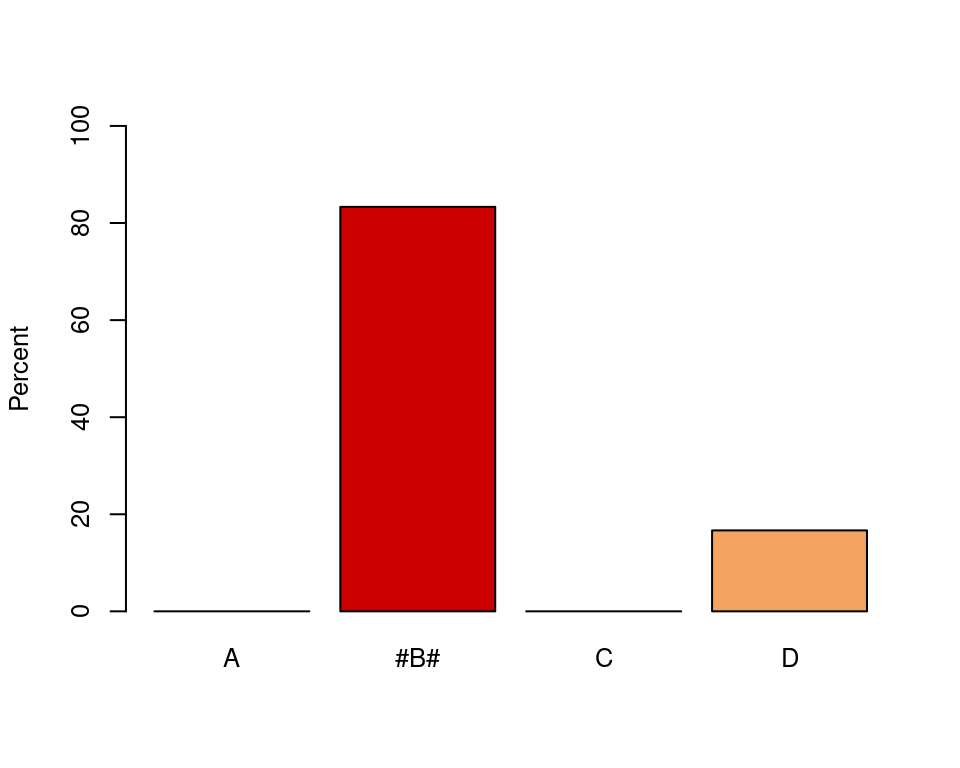

**Statistics for exam 25102300002; responses to Q.30**

| Response | Frequency | Percent | Biserial |
| --- | --- | --- | --- |
| #A# | 5 | 83.33 | 0.52 |
| B | 0 | 0.00 | NA |
| C | 0 | 0.00 | NA |
| D | 1 | 16.67 | -0.52 |
| Total | 6 | 100.00 | NA |

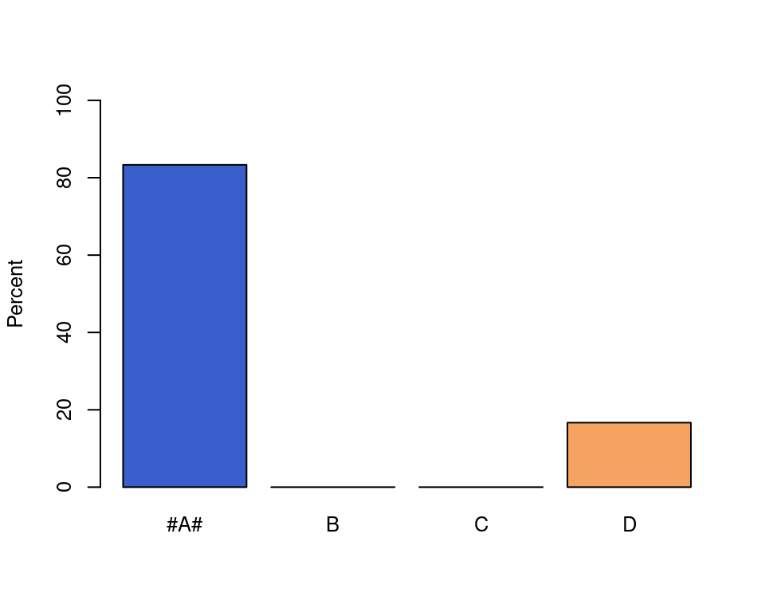

## Student grade barplot

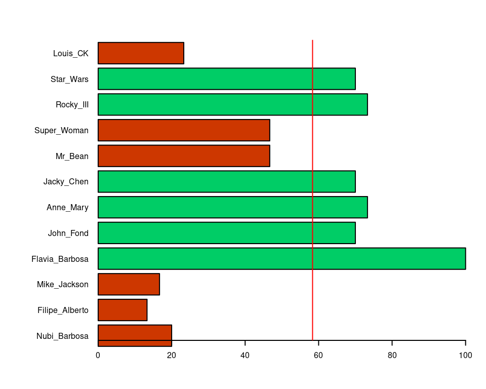

## Condensed test report summary

The stats in the table below are for all exams combined (when there is more than one type).

| **Total Points:** 30 | **Median Score:** 58.35 | **Lowest Score:** 13.3 |
| --- | --- | --- |
| **Total Students:** 12 | **Mean Score:** 51.94 | **Highest Score:** 100 |
| **Standard deviation:** 28.33 | **Reliability Coefficient (KR20)** 0.94 | **Score Range:** 13.3-100 |

## Test report by exam type

### Exam: 25102300001

| Question | Type | Correct | A | B | C | D | E | Non-distractor | Correct.Total | Upper.27% | Lower.27% | Biserial |
| --- | --- | --- | --- | --- | --- | --- | --- | --- | --- | --- | --- | --- |
| Responses.1 | Single | D | 0 | 33.33 | 0 | 66.67 | 0 | ACE | 66.67 | 33.33 | 0.00 | 0.94 |
| Responses.2 | Single | C | 0 | 16.67 | 66.67 | 16.67 | 0 | AE | 66.67 | 33.33 | 0.00 | 0.94 |
| Responses.3 | Single | C | 16.67 | 16.67 | 50 | 16.67 | 0 | E | 50.00 | 16.67 | 0.00 | 0.72 |
| Responses.4 | Single | A | 57.14 | 14.29 | 14.29 | 0 | 14.29 | D | 57.14 | 33.33 | 0.00 | 0.94 |
| Responses.5 | Single | E | 0 | 16.67 | 16.67 | 0 | 66.67 | AD | 66.67 | 33.33 | 0.00 | 0.94 |
| Responses.6 | Single | B | 0 | 66.67 | 16.67 | 16.67 | 0 | A | 66.67 | 33.33 | 16.67 | 0.39 |
| Responses.7 | Single | C | 16.67 | 16.67 | 33.33 | 33.33 | 0 |  | 33.33 | 33.33 | 0.00 | 0.66 |
| Responses.8 | Single | C | 16.67 | 33.33 | 16.67 | 33.33 | 0 |  | 16.67 | 16.67 | 0.00 | 0.62 |
| Responses.9 | Single | D | 33.33 | 16.67 | 16.67 | 33.33 | 0 |  | 33.33 | 16.67 | 0.00 | 0.62 |
| Responses.10 | Single | D | 16.67 | 50 | 16.67 | 16.67 | 0 |  | 16.67 | 16.67 | 0.00 | 0.62 |
| Responses.11 | Single | B | 0 | 83.33 | 16.67 | 0 | 0 | AD | 83.33 | 33.33 | 16.67 | 0.67 |
| Responses.12 | Single | D | 0 | 16.67 | 16.67 | 66.67 | 0 | A | 66.67 | 33.33 | 16.67 | 0.39 |
| Responses.13 | Single | B | 0 | 66.67 | 16.67 | 16.67 | 0 | A | 66.67 | 33.33 | 0.00 | 0.94 |
| Responses.14 | Multiple | BD | 8.33 | 41.67 | 8.33 | 25 | 16.67 |  | 50.00 | 33.33 | 0.00 | 0.75 |
| Responses.15 | Multiple | BC | 8.33 | 41.67 | 50 | 0 | 0 | DE | 83.33 | 33.33 | 16.67 | 0.52 |
| Responses.16 | Single | A | 83.33 | 16.67 | 0 | 0 | 0 |  | 83.33 | 16.67 | 33.33 | -0.22 |
| Responses.17 | Single | A | 50 | 50 | 0 | 0 | 0 |  | 50.00 | 33.33 | 0.00 | 0.75 |
| Responses.18 | Single | A | 83.33 | 16.67 | 0 | 0 | 0 | CD | 83.33 | 33.33 | 16.67 | 0.67 |
| Responses.19 | Single | B | 0 | 83.33 | 16.67 | 0 | 0 | AD | 83.33 | 33.33 | 16.67 | 0.52 |
| Responses.20 | Single | C | 16.67 | 33.33 | 50 | 0 | 0 | D | 50.00 | 16.67 | 0.00 | 0.72 |
| Responses.21 | Single | C | 33.33 | 16.67 | 50 | 0 | 0 | D | 50.00 | 33.33 | 0.00 | 0.75 |
| Responses.22 | Single | C | 16.67 | 33.33 | 50 | 0 | 0 | D | 50.00 | 33.33 | 0.00 | 0.75 |
| Responses.23 | Single | D | 33.33 | 16.67 | 0 | 50 | 0 | C | 50.00 | 33.33 | 0.00 | 0.75 |
| Responses.24 | Single | D | 0 | 33.33 | 0 | 66.67 | 0 | AC | 66.67 | 33.33 | 16.67 | 0.27 |
| Responses.25 | Single | A | 60 | 20 | 20 | 0 | 0 | D | 60.00 | 16.67 | 0.00 | 0.72 |
| Responses.26 | Single | E | 16.67 | 33.33 | 0 | 0 | 50 | CD | 50.00 | 16.67 | 0.00 | 0.72 |
| Responses.27 | Single | A | 50 | 0 | 33.33 | 16.67 | 0 | B | 50.00 | 33.33 | 0.00 | 0.75 |
| Responses.28 | Single | C | 0 | 33.33 | 66.67 | 0 | 0 | AD | 66.67 | 33.33 | 16.67 | 0.39 |
| Responses.29 | Single | D | 0 | 16.67 | 33.33 | 50 | 0 | A | 50.00 | 33.33 | 0.00 | 0.75 |
| Responses.30 | Single | A | 83.33 | 16.67 | 0 | 0 | 0 | CD | 83.33 | 33.33 | 16.67 | 0.67 |

### Exam: 25102300002

| Question | Type | Correct | A | B | C | D | E | Non-distractor | Correct.Total | Upper.27% | Lower.27% | Biserial |
| --- | --- | --- | --- | --- | --- | --- | --- | --- | --- | --- | --- | --- |
| Responses.1 | Single | A | 83.33 | 16.67 | 0 | 0 | 0 | CDE | 83.33 | 33.33 | 16.67 | 0.52 |
| Responses.2 | Single | D | 50 | 0 | 0 | 50 | 0 | BCE | 50.00 | 16.67 | 0.00 | 0.46 |
| Responses.3 | Single | B | 83.33 | 0 | 0 | 0 | 16.67 | BCD | 0.00 | 0.00 | 0.00 | NA |
| Responses.4 | Single | C | 0 | 16.67 | 50 | 16.67 | 16.67 | A | 50.00 | 16.67 | 0.00 | 0.46 |
| Responses.5 | Single | D | 0 | 0 | 0 | 66.67 | 33.33 | ABC | 66.67 | 33.33 | 0.00 | 0.88 |
| Responses.6 | Single | B | 16.67 | 33.33 | 16.67 | 33.33 | 0 |  | 33.33 | 16.67 | 16.67 | -0.07 |
| Responses.7 | Single | C | 0 | 50 | 50 | 0 | 0 | AD | 50.00 | 33.33 | 0.00 | 0.81 |
| Responses.8 | Single | D | 20 | 20 | 20 | 40 | 0 |  | 40.00 | 33.33 | 0.00 | 0.85 |
| Responses.9 | Single | D | 33.33 | 0 | 33.33 | 33.33 | 0 | B | 33.33 | 16.67 | 16.67 | -0.02 |
| Responses.10 | Single | A | 16.67 | 66.67 | 0 | 16.67 | 0 | C | 16.67 | 0.00 | 16.67 | -0.52 |
| Responses.11 | Single | C | 0 | 33.33 | 66.67 | 0 | 0 | AD | 66.67 | 33.33 | 0.00 | 0.88 |
| Responses.12 | Single | D | 0 | 0 | 33.33 | 66.67 | 0 | AB | 66.67 | 33.33 | 0.00 | 0.88 |
| Responses.13 | Single | C | 16.67 | 16.67 | 66.67 | 0 | 0 | D | 66.67 | 33.33 | 0.00 | 0.88 |
| Responses.14 | Multiple | ADE | 23.08 | 7.69 | 30.77 | 15.38 | 23.08 |  | 16.67 | 0.00 | 0.00 | 0.02 |
| Responses.15 | Multiple | B | 36.36 | 18.18 | 9.09 | 27.27 | 9.09 |  | 0.00 | 0.00 | 0.00 | NA |
| Responses.16 | Single | B | 33.33 | 66.67 | 0 | 0 | 0 |  | 66.67 | 33.33 | 16.67 | 0.45 |
| Responses.17 | Single | B | 66.67 | 33.33 | 0 | 0 | 0 |  | 33.33 | 16.67 | 0.00 | 0.47 |
| Responses.18 | Single | C | 16.67 | 66.67 | 16.67 | 0 | 0 | D | 16.67 | 16.67 | 0.00 | 0.50 |
| Responses.19 | Single | C | 16.67 | 50 | 33.33 | 0 | 0 | D | 33.33 | 16.67 | 16.67 | -0.07 |
| Responses.20 | Single | D | 0 | 16.67 | 16.67 | 66.67 | 0 | A | 66.67 | 33.33 | 0.00 | 0.88 |
| Responses.21 | Single | B | 16.67 | 83.33 | 0 | 0 | 0 | CD | 83.33 | 33.33 | 16.67 | 0.59 |
| Responses.22 | Single | B | 50 | 33.33 | 16.67 | 0 | 0 | D | 33.33 | 33.33 | 0.00 | 0.85 |
| Responses.23 | Single | C | 16.67 | 33.33 | 50 | 0 | 0 | D | 50.00 | 33.33 | 16.67 | 0.41 |
| Responses.24 | Single | A | 50 | 16.67 | 33.33 | 0 | 0 | D | 50.00 | 33.33 | 16.67 | 0.41 |
| Responses.25 | Single | A | 80 | 20 | 0 | 0 | 0 | CD | 80.00 | 33.33 | 0.00 | 0.88 |
| Responses.26 | Single | D | 33.33 | 66.67 | 0 | 0 | 0 | CDE | 0.00 | 0.00 | 0.00 | NA |
| Responses.27 | Single | A | 33.33 | 16.67 | 50 | 0 | 0 | D | 33.33 | 33.33 | 0.00 | 0.85 |
| Responses.28 | Single | D | 16.67 | 33.33 | 16.67 | 33.33 | 0 |  | 33.33 | 33.33 | 0.00 | 0.85 |
| Responses.29 | Single | B | 0 | 83.33 | 0 | 16.67 | 0 | AC | 83.33 | 33.33 | 16.67 | 0.59 |
| Responses.30 | Single | A | 83.33 | 0 | 0 | 16.67 | 0 | BC | 83.33 | 33.33 | 16.67 | 0.52 |